# MONITORING 2024 : PARCOURS D’ACCUEIL ET D’ACCOMPAGNEMENT DES PRIMO-ARRIVANTS ET DES PERSONNES ÉTRANGÈRES

Rapport annuel 2025  
Centre Bruxellois d’Action Interculturelle

### REMERCIEMENTS

Nous tenons à remercier ici l’ensemble des acteurs du parcours d’accueil (Bureau d’accueil, opérateurs de formation linguistique, partenaires) ainsi que l’Administration de la Commission Communautaire Commune (COCOM) et l’Administration de la Commission Communautaire Française (COCOF). C’est grâce à leur disponibilité et leurs explications des réalités de terrain que nous pouvons mieux comprendre ce dispositif.

# 1 INTRODUCTION

## 1.1 Objectifs et structure du rapport

Comme défini par l’Art. 82 de l’Arrêté de 2024 de la COCOM, ce **rapport annuel de monitoring** du dispositif “**Parcours d’accueil et d’accompagnement des primo-arrivants et personnes étrangères”** consiste en une synthèse des données administratives produites par les Bapas. Il vise à faire le suivi de la mise en œuvre concrète du dispositif.

Il se compose de quatre parties. La première consiste en une introduction au contexte territorial, à savoir les contextes migratoire et institutionnel, dans lequel prend place le parcours d’accueil francophone en Région de Bruxelles-Capitale.

Les trois parties suivantes visent à appréhender globalement le fonctionnement du parcours d’accueil. Basées sur des indicateurs quantitatifs standardisés, elles doivent permettre de saisir les évolutions de son fonctionnement au regard des années précédentes. À la demande des pouvoirs publics, nous y distinguons la catégorie des bénéficiaires et le genre des bénéficiaires quand cela est pertinent. Ces trois parties s’attachent à des aspects spécifiques du parcours :

- Partie II : l’organisation générale des bureaux d’accueil (stock de dossiers actifs et suspendus, flux d’admissions-inscriptions, ressources humaines, etc.).
- Partie III : les publics du parcours d’accueil (profils socio-démographiques) ;
- Partie IV : les actions mises en œuvre par les Bapas (suivies des activités du parcours d’accueil) ;

Nous concluons le rapport en pointant les enjeux et les perspectives auxquelles la politique d’accueil sera amenée à faire face dans les années à venir au regard des chiffres présentés.

## 1.2 Méthodologie : sources, données et démarche

Les analyses de ce rapport reposent principalement sur l’exploitation des données de l’Application Primo-Arrivants (APA), qui est l’outil employé par les travailleur·euses des Bapas pour gérer les dossiers des bénéficiaires[^1]. Le CBAI est chargé de produire des données agrégées à partir de cette base de données, de façon à alimenter la rédaction des rapports d’activités des Bapas. Ce rapport se base globalement sur les mêmes données et méthodologies[^2] que celles utilisées pour fournir aux Bapas les informations utiles à la rédaction de leurs rapports d’activités (extraction en janvier 2025).

Nous avons complété cette source principale en mobilisant les rapports d’activités des Bapas. Ceux-ci comprennent en effet des données, tant quantitatives (registre de présence) que qualitatives (témoignages de terrain), qui précisent, nuancent et contextualisent les données de l’APA. En particulier, les données qui ont trait à l’offre pour lesquelles les registres de présence des Bapas sont plus précis que l’APA (modules DD et FOCI).

Enfin, les données de la contextualisation territoriale (partie 1) proviennent de l’Institut Bruxellois de Statistique et d’Analyse (IBSA) – tant de leur site web pour les flux de l’immigration que d’une demande de données plus précise pour les effectifs de personnes primo-arrivantes et personnes étrangères –, ainsi que du Commissariat Général aux Réfugiés et aux Apatrides (CGRA) et du Centre fédéral Migration (Myria).

Concernant la démarche, il faut distinguer deux approches complémentaires de comptabilisation des dossiers des Bapas, et *ipso facto* des bénéficiaires, des activités et de la charge de travail des bureaux d’accueil, selon :

- une **logique de flux** : une somme d’individus et/ou de dossiers entrant (sortant) dans (d’)un territoire et/ou dispositif sur une durée déterminée (souvent une année) ;
- une **logique de stock** : une somme d’individus et/ou de dossiers sur un territoire ou dans un dispositif à une date précise (souvent à la fin ou au début de l’année).

Bien que ce monitoring mobilise les deux approches – les flux pour évaluer l’évolution des publics aux différentes étapes du dispositif et les stocks pour évaluer la charge de travail réelle des Bapas – la législation actuelle détermine le régime de subvention selon une logique de stock (le nombre de dossiers actifs au 31 décembre, peu importe l’année d’admission du bénéficiaire).

Au niveau de la présentation des données, dorénavant, nous distinguons deux catégories, les primo-arrivant·es et les personnes étrangères, définies par l’Ordonnance suite aux deux grandes modifications législatives qu’a connues la politique d’accueil en 2022 : l’obligation de suivi du parcours et l’élargissement du public aux personnes étrangères (cf. infra : Partie I). Cependant, sociologiquement, parmi les personnes étrangères deux sous-catégories peuvent être distinguées:

- les personnes étrangères, établies en Belgique depuis plus de trois ans,
- les primo-arrivant·es ayant-droit, établi·es en Belgique depuis moins de trois ans, mais non soumis·es à l’obligation.

Ces deux sous-catégories de bénéficiaires non-prioritaires ont été utilisées de manière ponctuelle, car elles permettent de mettre en lumière certains phénomènes observés dans le cadre d’analyses portant sur les évolutions du dispositif et des publics.

En outre, dans la perspective d’observer les tendances à l’œuvre, nous avons systématiquement comparé les chiffres de l’année 2024 avec ceux de l’année 2023 et avec la moyenne des années prépandémiques (2016-2019), ou à défaut, avec ceux de l’année 2019.

Enfin, il est important de noter que l’APA a connu plusieurs modifications importantes qui ont provoqué des **problèmes techniques ou des dysfonctionnements** au cours de l’année 2024. Ceci a compliqué l’exploitation des données, amenant à des limites qu’il convient de souligner.

Tout d’abord, l’année dernière nous avions déjà soulevé les problèmes techniques survenu avec certains changements de statut dans l’historique des dossiers – en particulier liés aux archivages automatiques de dossiers suspendus – n’étant pas toujours indiqués dans l’historique des dossiers[^3]. S’ajoute cette année le fait que le CBAI n’a pas eu accès aux motifs de suspensions. Une analyse des indicateurs relatifs aux suspensions n’a ainsi pas été possible.

Deux autres problèmes survenus en 2023, liés à la liaison entre la plateforme BruWelcome de la commune et l’APA, continuent d’avoir des incidences sur les données de 2024. Premièrement, les nationalités de certaines personnes prioritaires sont absentes. Cela est dû à des problèmes d’incompatibilité entre plateformes (Registre national, BruWelcome et APA) survenues en 2023; bien que résolues en 2024, certaines nationalités demeurent inconnues. Deuxièmement, la disparition des données relatives aux secteurs statistiques à partir de 2023, combinée à la restriction d’accès aux données des adresses, a fortement limité les analyses spatiales possibles, empêchant toute lecture à l’échelle infra-communale pour l’année 2024.

Ensuite, l’apparition de la liste d’attente et son développement pensée dans une logique statique plutôt que comme un statut de dossier, a entraîné des difficultés dans la comptabilisation des admissions, et a nécessité une révision de la méthodologie de calcul. Avant 2024, un·e bénéficiaire était considéré·e comme admis·e dès lors qu’il·elle remplissait les conditions d’admission du Parcours d’accueil. Cependant, avec la saturation du dispositif, les critères d’admission ne suffisent plus pour rentrer dans le parcours; désormais il faut tenir en compte les **capacités disponibles des Bapas à prendre en charge un·e bénéficiaire**. De manière progressive, le statut “*admis*” dans l’APA, auparavant associé à une admission effective, s’est transformé en un statut propre à la liste d’attente.

**Changement méthodologique**

**À partir de 2024, tout dossier passant du statut “*admis*” à “*actif*” sera considéré comme une admission**. Cette nouvelle définition s’applique rétroactivement aux données de 2023 pour les analyses évolutives, afin d’assurer l’exclusion des personnes en liste d’attente à cette époque dans le calcul des admissions. Cela peut entraîner des écarts avec les chiffres publiés dans le Monitoring de 2023.

Cependant, deux ajustements ont dû être faits lors du calcul des admissions. Premièrement, 13 dossiers de primo-arrivant·es étaient en statut “*admis*”, alors qu’à cette date, aucune personne soumise à l’obligation ne peut être placée en liste d’attente ou non-admissible. Ces dossiers ont été considérés comme actifs et comme des admissions en 2024. Deuxièmement, le développement de la liste d’attente continue à connaître des ajustements techniques. L’une des dernières modifications, implémentée à la demande des Bapas, consiste à faire disparaître le nom du Bapa auprès duquel une personne étrangère est inscrite sur liste d’attente lorsqu’elle ne se présente pas après le délai de trois mois. Au total, 56 personnes étrangères se retrouvaient ainsi sans nom de Bapa associé, tout en ayant un dossier actif. Il s’agit d’ancien·nes bénéficiaires dont le dossier, lors de l’inscription en liste d’attente, a été réactivé au statut qu’il occupait avant son archivage. Ces personnes n’ont donc pas été considérées comme admises en 2024. Ces deux rectifications ont été faites après l’envoi des données aux Bapas pour leurs rapports d’activités.

Enfin, dans le cadre de notre recherche de 2025, nous travaillons sur l’exercice de monitoring ce qui entraîne indirectement l’analyse approfondie de l’APA. À ce titre, nous avons réalisé des entretiens avec les coordinations des Bapas et exploré la base de données, en nous concentrant dans un premier temps sur les bilans sociaux et linguistiques. Dans cette première phase de recherche, nous avons constaté que certaines dates de bilans sociaux et linguistiques disparaissaient, alors qu’elles constituent l’indicateur principal pour le décompte. Nous avons donc décidé d’actualiser dès ce monitoring notre méthode.

**Changement méthodologique**

A partir de 2024, un bilan social ou linguistique est désormais considéré comme réalisé pendant l’année en cours : s’il comporte une date de réalisation correspondant à cette même année, ou s’il comporte au moins quatre parties remplies pour un·e bénéficiaire admis·e au cours de cette même année.

Ces limites seront également explicitées dans les parties concernées. Malgré cela, les chiffres permettent d’analyser les évolutions qu’a connu le parcours d’accueil depuis le début de sa mise en œuvre jusqu’à aujourd’hui ainsi que les nouvelles tendances subséquentes aux changements législatifs.

# 2 LE CONTEXTE DE MISE EN ŒUVRE DU PARCOURS D’ACCUEIL

## 2.1 Contexte institutionnel : les effets des réformes législatives

L’année 2024 est marquée par la **consolidation et l’évolution des deux réformes législatives** majeures que les Bapas ont dû gérer simultanément. D’une part, la pleine **mise en œuvre de l’obligation de suivi depuis juin 2022** et d’autre part, **depuis décembre 2022,** **l’élargissement du public aux personnes étrangères**. Bien que ces changements soient entrés en vigueur en 2022, leur impact sur le public et sur le travail des Bapas continue à être visible cette année, d’où l’importance d’en faire le monitoring.

Les résultats de notre rapport de recherche de 2024 ont montré que les principaux effets de ce double changement législatif ont été la **diversification des profils et des besoins** des publics ainsi que l’**intensification des admissions jusqu’à la** **saturation généralisée du Parcours d’accueil en 2024**[^4]. Face à cette situation, un système de liste d’attente a été mis en place dès la fin de l’année 2023, pour les personnes étrangères souhaitant accéder au parcours d’accueil. La liste d’attente vise donc à adapter l’offre aux capacités budgétaires et structurelles des Bapas tout en préservant des places pour le public obligé. La saturation a eu des effets importants :

- **Sur les équipes des Bapas** : confrontées à une **charge de travail en forte augmentation**, marquée notamment par l’**inflation du travail administratif**, qui a amené à l’**affaiblissement de l’accompagnement social** et, pour de nombreux·ses travailleur·euses, un **sentiment de perte de sens** dans leur mission.
- **Sur leur** **public** : en plus de subir les potentielles conséquences de l’affaiblissement de l’accompagnement social, il se trouve **pris entre deux réalités** : d’une part, les **primo-arrivant·es obligées confronté·es à des difficultés de suivi** ; d’autre part, les **personnes étrangères** souhaitant introduire une demande de nationalité belge, mais **ne pouvant actuellement s’inscrire dans le dispositif** faute de place.

Ensuite, depuis le 1er janvier 2024, le dispositif francophone « parcours d’accueil » est passé **sous tutelle de Vivalis** (ex-SCR de la COCOM) – autorité qui organise l’obligation depuis juin 2022 – qui agrée les ex-BAPAs francophones et exerce désormais cette compétence via l’ordonnance du 20 juillet 2023. Le dispositif Cocom est dénommé « Parcours d’accueil et d’accompagnement des primo-arrivants et des personnes étrangères ». Nous décrivons dans ce rapport, le passage de l’exercice de la compétence sous l’égide de Vivalis par le terme de « cocomisation du parcours d’accueil », tel que défini aussi dans le débat politique et médiatique.  
Dans le cadre de la “cocomisation”, les Bapas ont dû adapter leurs pratiques afin de se conformer à l’Arrêté du 18 janvier 2024 et à l’Ordonnance du 20 juillet 2023 de la COCOM. Ces évolutions ont entrainé plusieurs **changements structurels et organisationnels** notables, parmi lesquels :

- la production de nouveaux outils bilingues de communication en français et néerlandais ;
- la mise en place de la collaboration avec la Huis van het Nederlands ;
- la suppression du volet primaire et secondaire dans l’organisation du parcours d’accueil ;
- la possibilité, pour les Bapas qui le souhaitent, de fusionner les modules de Droits et Devoirs et de Citoyenneté en une seule formation de 60h ;
- le relèvement du niveau de langue requis pour les bénéficiaires en filière d’alphabétisation, passant de A1 oral à A2 oral.

Aussi, la Commission communautaire française reste compétente pour le volet « formations linguistiques ». Elle abroge ainsi le décret instaurant un parcours d’accueil du 18 juillet 2013 et se dote d’un nouveau décret pour agréer des opérateurs linguistiques en charge de dispenser des formations de français jusqu’au niveau A2 de CECR et jusqu’au niveau A2 pour les seules compétences orales dans la filière d’alphabétisation.

Le nouveau cadre législatif de la COCOM définit deux catégories de public cible :

1. **Les primo-arrivant·es** (prioritaires et non-exempté·es de l’obligation) : toutes les personnes étrangères majeures de moins de 65 ans, originaires d’un pays hors de l’UE27+ et ne remplissant pas l’une des autres conditions d’exemption[^5], séjournant légalement en Belgique depuis moins de trois ans, et inscrit·es avec un titre de séjour de plus de trois mois au registre national d’une commune de la RBC.
2. **Les personnes étrangères** (non-prioritaires ou exemptées de l’obligation) **:** toute personne étrangère majeure, inscrite au registre des étrangers ou de la population d’une commune du territoire bilingue de la RBC et disposant d’un titre de séjour de plus de trois mois et qui n’est pas obligée de suivre le parcours d’accueil.

En 2024, le parcours d’accueil pour primo-arrivant·es est mis en œuvre par **trois associations agréées par la Cocom** (BAPA) : **VIA** et **BAPA-BXL**, actives depuis 2016, ainsi que **Convivial**, reconnue depuis 2020. Ces opérateurs interviennent sur **cinq implantations**, les activités de VIA et de Convivial étant réparties chacun sur deux sites chacun : VIA opère à Schaerbeek et Molenbeek, tandis que Convivial intervient à Forest et, depuis début 2024, à Anderlecht. Si VIA et BAPA-BXL ont l’agrément de type IV depuis 2016 (capacité de 2.000 dossiers actifs), Convivial a obtenu l’agrément de type III en juillet 2022 (1.500 dossiers actifs) et l’agrément de type IV fin 2023 en parallèle à l’ouverture de son antenne à Anderlecht début 2024.

## 2.2 Contexte territorial : immigration, séjours et publics cibles

La parcours d’accueil bicommunautaire pour primo-arrivant·es (Cocom) est mis en œuvre sur le territoire de la Région de Bruxelles-Capitale (RBC). Toutefois, certaines données contextuelles ne sont disponibles qu’à l’échelle nationale[^6], comme les données relatives aux titres de séjour et aux demandes de protection internationale. Les données sur les flux d’immigration internationale et les personnes étrangères, dont les primo-arrivantes, concernent quant à elles la RBC.

### 2.2.1 L’immigration internationale en RBC

En 2024, les personnes étrangères en RBC représentent 37 % de la population régionale. Cette proportion est largement supérieure aux deux autres régions belges (11 % chacune)[^7]. De même, la part des personnes nées à l’étranger atteint 60 %, contre 22 % en Wallonie et 19 % en Flandre. Parmi ces personnes nées à l’étranger, 58 % ont des nationalités hors de la zone UE-27 en RBC et en Flandre, contre 44 % en Wallonie. Cette part ne cesse d’augmenter depuis les 20 dernières années et montre ainsi la diversification de l’immigration tant en termes de nationalités que de motifs (cf. Infra : titre de séjours). Notons que la nationalité française est la première nationalité étrangère depuis 2005 en RBC et représente 6% de la population totale de la Région bruxelloise en 2024 (70.830 personnes). La suivent les Roumain·es (3,7%), les Italien·nes (2,9%), et puis les Marocain·es (2,6%).

La population étrangère récemment arrivée à Bruxelles est importante. En moyenne, au cours des cinq dernières années (2019-23), la Région a accueilli chaque année plus de 49.000 personnes en provenance de l’étranger. Plus concrètement, sur les 1.250.000 habitant·es que compte la Région au 1<sup>er</sup> janvier 2024, plus de 500.000 habitants n’étaient pas présents 10 ans auparavant : 124.000 personnes sont nées entre 2014 et 2024, 122.000 ont déménagé depuis une autre Région belge, et 260.000 ont immigré depuis l’étranger. Au début de l’année 2024, on peut donc considérer que 21% des Bruxellois·es sont arrivé·es dans la capitale à la suite d’une immigration internationale au cours des dix dernières années.

Si l’immigration ukrainienne a fortement reculé en 2023 (le groupe “Reste de l’Europe” chute de 60% par rapport à 2022), le flux total des premières entrées reste supérieur aux années 2010 (52.291 immigrants). Du point de vue des (autres) nationalités, bien que les ressortissant·es des Nouveaux États membres de l’UE diminue (-9%), les pays de l’UE27 représentent toujours plus de la moitié des premières entrées (55%). On notera encore les augmentations relativement significatives des personnes issues d’Afrique subsaharienne (+25%) et de Turquie (+21%).

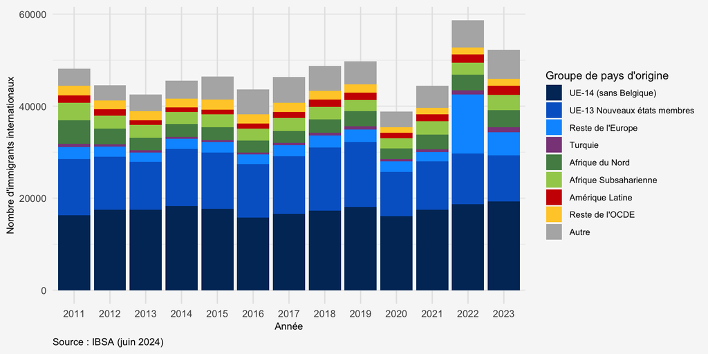

Figure 1: Évolution de l’immigration internationale en RBC (2011-2023).

### 2.2.2 Les premiers titres de séjour en Belgique

Les dernières données disponibles de Myria sur les titres de séjour datent de 2022. En 2022, 171.405 premiers titres de séjour[^8] ont été délivrés, ce qui représente le chiffre plus important depuis 2010. Ceci est lié à l’arrivée massive de personnes déplacées suite à la guerre entre l’Ukraine et la Fédération de Russie. Ainsi, contrairement aux années précédentes **la grande part, près de deux tiers (64 %), des premiers titres de séjour a été délivrée à des ressortissants·es de pays tiers**, soit 109.295 pour 62.110 pour les citoyens·nes européens·nes. Le nombre de premiers titres de séjour délivrés aux ressortissants de pays tiers a doublé (+105 %) par rapport à 2021 principalement par le nombre de bénéficiaires de la protection temporaire. Ceux-ci représentent près de la moitié des titres de séjour délivrés (47 % soit 51.721), parmi lesquels la grande majorité (99 %) sont des Ukrainiens·nes.

Concernant les motifs de séjour en 2022, plus de la moitié des premiers titres de séjour des citoyen·nes de l’UE sont octroyés pour des raisons liées à une activité rémunérée (51% - et 58% en y ajoutant les études). Tandis que pour les ressortissant·es de pays tiers, ce sont les raisons familiales (21%), suivies des études (8%), et enfin les activités économiques (7%) et la protection internationale (7%). Notons que pour les premiers titres de séjour délivrés, le motif lié à la famille a augmenté de 37% par rapport à 2020 et de 19 % par rapport à 2018. Si l’on déduit le nombre de protections temporaires en 2022 (BPTU), les raisons liées à la famille représentent 41% des premiers titres de séjour. Le regroupement familial devient ainsi une des principales voies dans l’accès au territoire.

Concernant les protections internationales (Figure 2), après la baisse liée à la pandémie mondiale (2020-21), les premières demandes de protection internationale (moyenne des années 2022, 2023 et 2024) ont quasi doublé (+88%), et ont même augmenté par rapport à la période pré-pandémie (+35% par rapport à 2019). En 2024, 33.146 premières demandes de protection internationale (réinstallation inclue) ont été enregistrées.

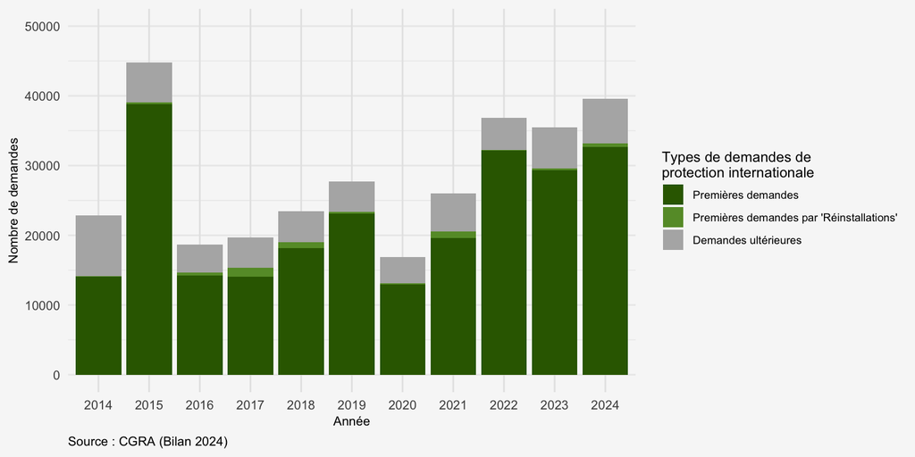

Figure 2: Évolution du nombre de premières demandes de protection internationale (2014-2024).

Parmi celles-ci, la Palestine, avec 5.332 premières demandes de protection internationale, continue d’augmenter fortement (+80% par rapport à 2023) et se positionne dorénavant à la première place avec la Syrie (5.347)[^9]. Ces deux premières nationalités représentent un tiers des premières demandes en 2024. On notera encore, dans le top-10 des nationalités, la consolidation de l’Érythrée à la troisième place (+ 56%), et la chute de l’Afghanistan (-26%), la Turquie (-16%), et la Guinée (-15%).

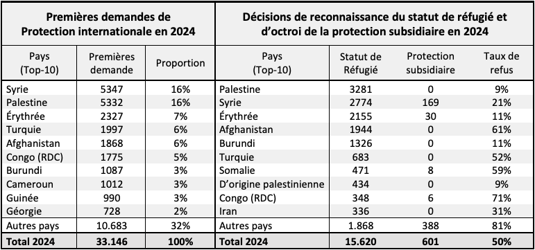

Les premières demandes de Protection internationale et les décisions de reconnaissance selon les dix premières nationalités. Source : CGRA (Bilan 2024)

En somme, si les Bapas ont commencé leur travail dans un contexte migratoire marqué par un afflux exceptionnel de demandes d’asile (la « crise des Syriens » en 2015), la reconnaissance du statut de réfugié a diminué au fil des années malgré sa relative reprise depuis le début de la pandémie avec un taux de refus redescendu sous les 60% (Figure 3). Ainsi, cette voie d’accès au territoire a eu globalement tendance à légèrement se réduire.

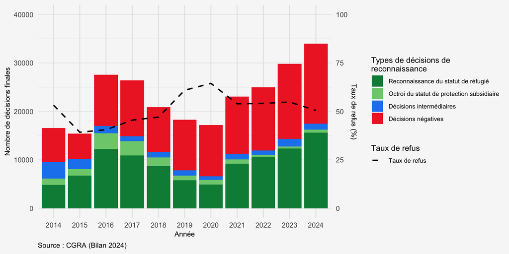

Figure 3: Évolution du nombre de types de décisions (2014-2024).

### 2.2.3 Les publics ciblés par le Parcours d’accueil

Après avoir exposé les flux de l’immigration en RBC et les reconnaissances et motifs de séjour en Belgique, nous présentons dans ce deuxième sous-point le poids démographique (1.2.3.1) et la géographie (résidentielle) des deux publics cibles du Parcours d’accueil : les personnes primo-arrivantes (1.2.3.2) et les “personnes étrangères” (1.2.3.3) .

#### 2.2.3.1 L’importance régionale des publics cibles

Le poids démographique de ces publics ciblés par le Parcours d’accueil est proportionnellement plus important en RBC que dans les deux autres régions – *grosso modo* un rapport de trois (Table 1). Ce rapport s’observe autant de façon agrégée, c’est-à-dire sur l’ensemble des personnes étrangères, qu’au niveau des sous-catégories de personnes étrangères relatives à leur durée de séjour (plus ou moins de trois ans).

|  | RBC Effectif | RBC Proportion | Flandre Effectif | Flandre Proportion | Wallonie Effectif | Wallonie Proportion | Belgique Effectif | Belgique Proportion |
| --- | --- | --- | --- | --- | --- | --- | --- | --- |
| Personnes étrangères actives (totale) | 349 654 | 43 % | 528 516 | 13 % | 274 349 | 12 % | 1 152 519 | 16 % |
| Primo-arrivants (>3ans) | 101 037 | 12 % | 162 080 | 4 % | 60 518 | 3 % | 323 635 | 5 % |
| hors-UE27+ | 46 139 | 6 % | 90 540 | 2 % | 34 497 | 2 % | 171 176 | 2 % |
| Personnes étrangères (>3ans) | 248 617 | 31 % | 366 436 | 9 % | 213 831 | 10 % | 828 884 | 12 % |
| hors-UE27+ | 126 355 | 16 % | 219 334 | 5 % | 96 010 | 4 % | 441 699 | 6 % |
| Population active (totale) | 814 524 | 100 % | 4 044 840 | 100 % | 2 216 983 | 100 % | 7 076 347 | 100 % |

Source : Source : IBSA & Statbel (Direction générale Statistique – Statistics Belgium) (Registre national) (juin, 2024)

Table 1: Poids régionaux des publics cibles du Parcours d’accueil (effectifs et proportions par région par rapport à la population active totale (18-64 ans).

Au 1er janvier 2024, **le nombre de personnes primo-arrivantes récentes hors-UE27+**, c’est-à-dire arrivées l’année qui précède cette date (2023), **s’élevait à 17.069 en RBC**. Ce flux annuel de personnes potentiellement soumises à l’obligation est bien supérieur à l’estimation du 1<sup>er</sup> janvier 2021 – en pleine pandémie – réalisée par le CBAI (10.518 primo-arrivant·es). Il n’est pas inintéressant de mettre ce dernier chiffre en regard avec celui des places disponibles : la double politique d’accueil en RBC - le Parcours d’accueil bicommunautaire (BAPA) et l’*inburgeringtraject* (BON) - finance ensemble 10.000 parcours par an (6.000 et 4.000, respectivement).

#### 2.2.3.2 Les primo-arrivant·es en RBC

Dans cette partie, nous présentons le **stock** de personnes primo-arrivantes (PA), qu’elles soient prioritaires ou non, au **1er janvier 2024**, par commune et à l’échelle des secteurs statistiques (Table 2*)*. Nous distinguons les PA originaires de l’UE27- exempté·es de l’obligation de suivi, et par conséquent non-prioritaires - de celles et ceux issu·es de pays tiers (hors UE27+) - c’est-à-dire **potentiellement soumis·es à l’obligation** (sans autres motifs d’exemption)*.* Ces chiffres ne prétendent donc pas donner un volume exhaustif des personnes effectivement concernées par l’obligation, mais plutôt donner une indication de la structure spatiale de leur répartition en RBC.

| Communes | Primo-arrivant·es (total) Effectif | Primo-arrivant·es (total) Part du total de PA de la région (%) | Primo-arrivant·es (total) Part cumulée | Primo-arrivant·es hors-UE27+ Effectif | Primo-arrivant·es hors-UE27+ Part du total de PA de la commune (%) | Primo-arrivant·es hors-UE27+ Quotien de localisation (spécificité régionale) |
| --- | --- | --- | --- | --- | --- | --- |
| Bruxelles | 21086 | 20,9 | 20,9 | 9602 | 45,5 | 1,00 |
| Ixelles | 13832 | 13,7 | 34,6 | 4405 | 31,8 | 0,70 |
| Schaerbeek | 9185 | 9,1 | 43,7 | 4272 | 46,5 | 1,02 |
| Anderlecht | 7584 | 7,5 | 51,2 | 4286 | 56,5 | 1,24 |
| Etterbeek | 6722 | 6,7 | 57,8 | 2275 | 33,8 | 0,74 |
| St-Gilles | 6173 | 6,1 | 63,9 | 2159 | 35,0 | 0,77 |
| Woluwe St-Lambert | 5083 | 5,0 | 68,9 | 2588 | 50,9 | 1,11 |
| Uccle | 4935 | 4,9 | 73,8 | 2039 | 41,3 | 0,90 |
| Molenbeek St-Jean | 4223 | 4,2 | 78,0 | 2957 | 70,0 | 1,53 |
| Forest | 3384 | 3,3 | 81,4 | 1437 | 42,5 | 0,93 |
| St-Josse-ten-Noode | 3151 | 3,1 | 84,5 | 1346 | 42,7 | 0,94 |
| Evere | 3048 | 3,0 | 87,5 | 2040 | 66,9 | 1,47 |
| Jette | 2927 | 2,9 | 90,4 | 1662 | 56,8 | 1,24 |
| Woluwe St-Pierre | 2745 | 2,7 | 93,1 | 1251 | 45,6 | 1,00 |
| Auderghem | 2376 | 2,4 | 95,5 | 1308 | 55,1 | 1,21 |
| Koekelberg | 1618 | 1,6 | 97,1 | 893 | 55,2 | 1,21 |
| Ganshoren | 1194 | 1,2 | 98,2 | 617 | 51,7 | 1,13 |
| Berchem Ste-Agathe | 889 | 0,9 | 99,1 | 521 | 58,6 | 1,28 |
| Watermael-Boitsfort | 882 | 0,9 | 100,0 | 481 | 54,5 | 1,19 |
| Région de Bruxelles-Capitale | 101037 | 100,0 | 100,0 | 46139 | 45,7 | 1,00 |

Source : Source : IBSA & Statbel (Direction générale Statistique – Statistics Belgium) (Registre national) (juin, 2024)

Table 2: Répartition des personnes primo-arrivantes selon les communes de résidence

On constate premièrement que **quatre communes concentrent à elles seules la moitié (51%) des personnes primo-arrivantes** : la Ville de Bruxelles (21%), Ixelles (14%), Schaerbeek (9%), Anderlecht (7,5%). Ces proportions sont identiques à l’année dernière. Toutefois, si l’on s’intéresse non pas aux effectifs absolus mais au degré de spécialisation (quotient de localisation[^10]) des personnes primo-arrivantes « potentiellement prioritaires » (hors EU27+), ce classement communal est différent : Molenbeek (1,53), Evere (1,47), Berchem-Sainte-Agathe (1,28), Anderlecht (1,24) et Jette (1,24), etc. On note encore que les communes de la première couronne sud-est - telles qu’Etterbeek, Ixelles et Saint-Gilles - comptent des effectifs importants de primo-arrivant·es, mais sont nettement moins spécifiques aux ressortissant·es de pays tiers.

Ces constats apparaissent plus nettement encore à l’échelle **infracommunale** (Figure 4). Si les primo-arrivant·es sont nombreux (en effectif absolu) dans les quartiers sud et sud-est de la première couronne, les personnes primo-arrivantes extra-européennes y sont nettement moins représentées (en part relative) qu’à l’ouest et au nord de la Région. Certains quartiers de la deuxième couronne méritent une attention particulière :

- **Evere**, où l’on observe une présence marquée de la communauté indienne[^11] ;
- **Ixelles**, avec une concentration d’étudiant·es étranger·ères dans les quartiers universitaires (ULB-VUB), et qui sont souvent exempté·es de l’obligation ;
- ainsi que quelques **quartiers “diplomatiques”** spécifiques du sud-est de la RBC (Uccle, Woluwe-Saint-Pierre), où résident des fonctionnaires de missions étrangères (comme les ambassades de Russie ou de Chine), et dont le personnel est également exempté·es.

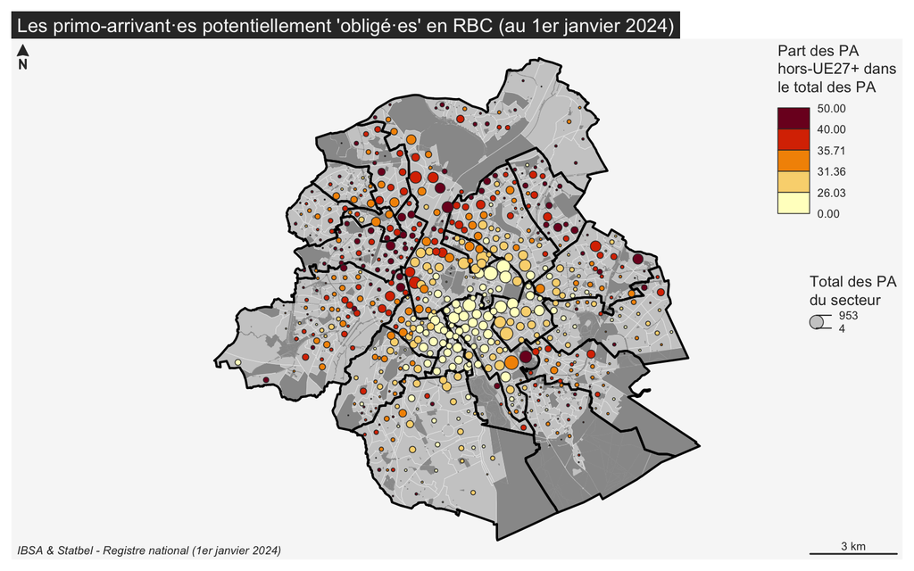

Figure 4: Géographie résidentielle des personnes primo-arrivantes au 1er janvier 2024

#### 2.2.3.3 Les personnes étrangères en RBC

La géographie résidentielle des personnes étrangères (titulaire d’un titre de séjour de plus de trois ans) rejoint celle des primo-arrivant·es. On y retrouve notamment le **clivage nord-ouest / sud-est** **en** **matière de spécialisation des quartiers pour les ressortissant·es hors UE27+.** Toutefois, les quartiers du nord-ouest, et y compris ceux de la deuxième couronne, affichent des effectifs (absolus) nettement plus élevés de ressortissant·es de pays tiers que ceux observés pour les primo-arrivant·es. Ce constat peut être mis en perspective avec les dynamiques résidentielles à l’œuvre dans la Région, notamment des personnes issues de l’immigration internationale, déjà documentées par ailleurs.[^12].

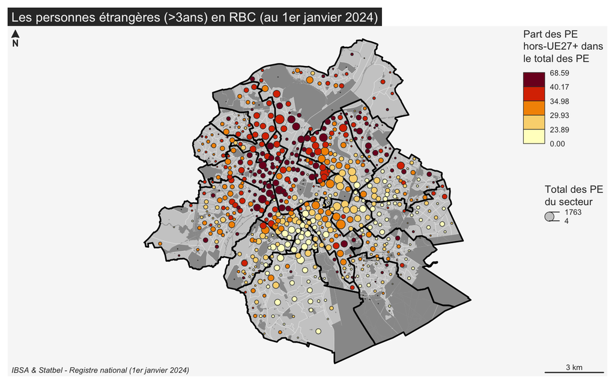

Figure 5: Géographie résidentielle des personnes étrangères (>3ans) au 1er janvier 2024

# 3 ORGANISATION DU DISPOSTIF

Nous présentons tout d’abord les données des Bapas dans une logique de flux, c’est-à-dire les **dossiers admis** (ou effectivement inscrits) au cours d’une période donnée, en l’occurrence l’année 2024. Nous nous penchons ensuite sur le stock de **dossiers actifs**, c’est-à-dire le nombre de dossiers activement en cours de parcours à une date précise, en l’occurrence **le 31 décembre 2024**. La logique de stock permet de mettre en évidence le report de charge annuelle (dossiers admis avant 2024 et toujours actifs à cette date), et ainsi de mieux saisir la charge de travail réelle des Bapas au regard des ressources humaines disponibles. Nous aborderons également deux formes moins visibles de la charge de travail : d’une part, la charge latente et différée liée aux **dossiers suspendus** (réactivables à tout moment) ; d’autre part, la pression à l’entrée des Bapas que représentent les **dossiers placés en liste d’attente**. Ce mécanisme de mise en attente a été instauré à la fin de l’année 2023, afin de faire face à la saturation généralisée du dispositif, elle-même causée par les réformes législatives de 2022.

**Important**

Dans ce deuxième chapitre, nous ventilons, dans certains cas, les effectifs en plusieurs sous-catégories qui dépassent les deux seules catégories de la législation : Primo-arrivant·es (public prioritaire) et Personnes étrangères (public non-prioritaire). En effet, pour saisir les enjeux organisationnels, il convient de distinguer des sous-groupes parmi le public non-prioritaire :

- Les **personnes étrangères** qui ont un séjour légal de plus de 3 ans et qui viennent essentiellement dans le cadre de la demande de nationalité ;
- Les **Primo-arrivant·es ayant droit** arrivé·es avant l’obligation de suivi (1er juin 2022) ;
- Les **Primo-arrivant·es exempté·es** de l’obligation de suivi.

Dans certains graphiques, les deux dernières sous-catégories sont combinées sous le terme de “Primo-arrivant·es ayant droit”.

## 3.1 L’évolution du flux d’admissions

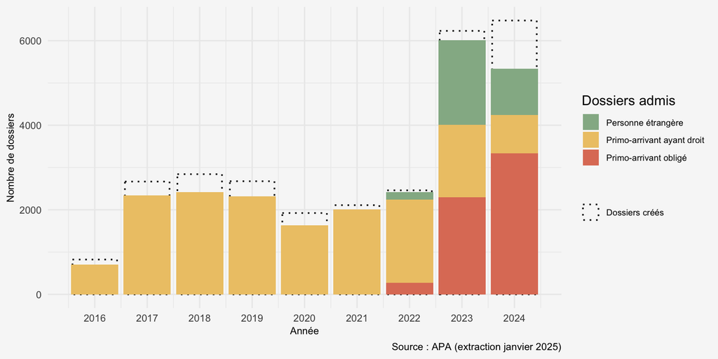

Figure 6: Évolution annuelle du flux d’admissions selon la catégorie de bénéficiaires

La répartition du public selon les catégories de bénéficiaires est nettement moins équilibrée qu’en 2023. Les **Primo-arrivant·es obligé·es** r**eprésentent désormais** **près des deux tiers du public des Bapas (63 %)**, contre un peu plus d’un tiers (36 %) en 2023. À côté de ce public prioritaire, les Personnes étrangères constituent un cinquième du public (20 %), tandis que la part des Primo-arrivant·es ayant droit est encore moindre (17 %). **La forte diminution du public non prioritaire par rapport à 2023 (-46%) s’explique par la mise en place de la liste d’attente** et, dans une moindre mesure, par la diminution de l’effectif de Primo-arrivant·es ayant-droit admis ou ayant obtenu un titre de séjour avant l’entrée en vigueur de l’obligation (période de transition).

Au niveau des Bapas (Figure 7), nous observons des disparités dans la répartition des catégories de bénéficiaires. Tout d’abord, si le **public prioritaire** **représente en 2024 plus de la moitié des admissions des trois Bapas**, ce public est nettement plus important à BAPA-BXL (82% des dossiers admis) qu’à VIA (57%) et Convivial (52%). Pour ces derniers, la répartition des admissions des deux catégories de public non prioritaire est toutefois différente : à VIA la part des Primo-arrivants ayant droit représente encore un quart des admissions, tandis qu’à Convivial, la part des personnes étrangères est plus importante. Ce dernier constat s’explique notamment par une saturation plus tardive de Convivial, par ailleurs passé en Catégorie IV en janvier 2024 (+ 500 places). Cette augmentation de capacité a permis d’attirer plus longtemps ce public non prioritaire, alors que les Bapas historiques étaient déjà saturés depuis fin 2023, jusqu’à la saturation à la fin de l’été 2024.

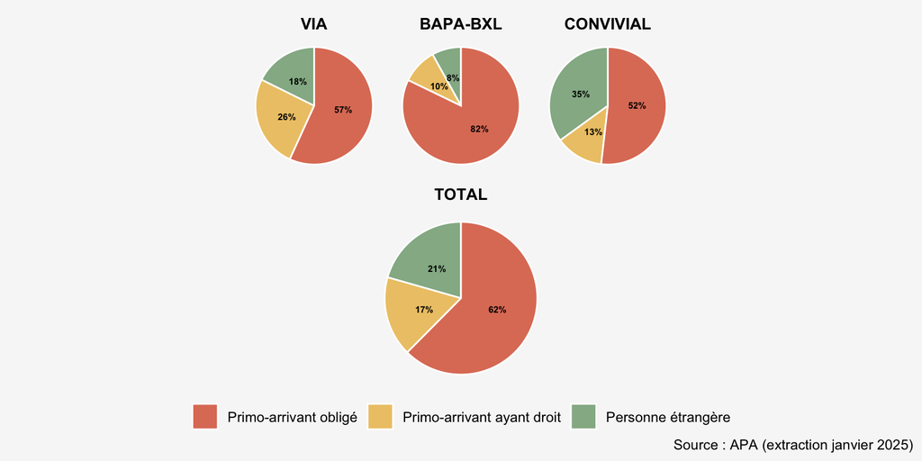

Figure 7: Répartition des admissions selon la catégorie de bénéficiaires et l’opérateur

## 3.2 L’évolution du stock de dossiers actifs

L’indicateur le plus pertinent pour évaluer la charge de travail réel des Bapas sont les dossiers actifs, vu que ces derniers donnent une mesure du stock de bénéficiaires dans le parcours, peu importe l’année d’admission et peu importe où se trouve le bénéficiaire au sein du parcours.

En 2024, alors que **la moyenne du stock de dossiers actifs chaque jour de l’année (5.600)** reste en-deçà du seuil de saturation (6.000), ce seuil était atteint en décembre avec **6.007 dossiers actifs.**

Le graphique de l’évolution mensuelle du nombre moyen de dossiers actifs (Figure 8) montre en effet qu’après une réduction massive des dossiers actifs en 2022 (nettoyage des dossiers “inactifs” en vue de l’augmentation attendue des recours avec les réformes législatives), ces derniers ont fortement augmenté depuis le début de l’année 2023. Si on observe un léger ralentissement à la fin 2023, en raison de la saturation du dispositif, l’accroissement du stock de dossiers actifs à repris dès le début de l’année 2024 avec le passage en catégorie IV du BAPA Convivial (+ 500 places/dossiers). En définitive, depuis janvier 2023, **le taux d’accroissement mensuel moyen de dossiers actifs est de 2,3%**.

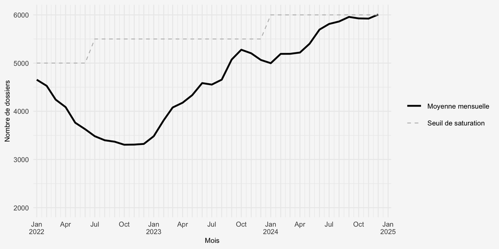

Figure 8: Évolution mensuelle du stock moyen de dossiers actifs

## 3.3 Situation générale : un dispositif saturé

Le dispositif connait pour la première fois en 2024 **une saturation généralisée** : les trois Bapas étant saturés à partir du mois de septembre. Au 31 décembre 2024, 826 personnes non-prioritaires figurent sur la liste d’attente.

Cette situation peut être illustrée par deux indicateurs :

- Le **taux de surpopulation**[^14] s’élève, au 31 décembre 2024, à **114%**, signifiant que 14% de la demande (public non prioritaire) n’est pas rencontrée faute de places.
- Le **taux d’exclusion du public non-prioritaire**[^15]- vu que seul ce public est pour l’instant victime de cette saturation (et peut être placé sur liste d’attente) - s’élève à **30%** en 2024 (une sous-estimation vu que certaines personnes disparaissent de la liste d’attente, si cette attente n’est pas prolongée).

Le graphique synthétique suivant (Figure 9) met en perspective l’évolution du stock de dossiers actifs avec ceux des dossiers suspendus et de la liste d’attente au 31 décembre 2024, mais aussi au regard du solde entre les flux entrants et sortants. Deux informations peuvent en être tirées.

On observe tout d’abord, outre l’augmentation des dossiers actifs par rapport à l’année dernière (+7%), que **les dossiers suspendus ont presque doublé (+90%)** et que **la liste d’attente a presque triplé (260%)**. Ainsi, au 31 décembre 2024, on dénombre 6.013 dossiers actifs, **7.086 dossiers potentiellement actifs** (actifs et suspendus), et en y ajoutant la liste d’attente, un total de 7.912 dossiers, soit une augmentation de 23% par rapport à l’année précédente.

On note ensuite que le solde des flux entrants (dossiers admis) et sortants (parcours terminés) a diminué en 2024 (-34% par rapport à 2023)**.** Cette baisse résulte à la fois de la mise en place de la liste d’attente (permettant de ralentir les entrées), mais aussi d’un renforcement progressif du nombre de modules de formation (citoyenne), réduisant le temps d’attente avant son suivi effectif, et donc les durées de parcours (cf. infra : chapitre 4). **Toutefois,** **ce report de charge** **(+2.292 dossiers)** **reste largement positif - l’équivalent de la capacité d’un opérateur - et ne permet pas à ce jour de réduire substantiellement la liste d’attente actuelle (826 personnes au 31 décembre),** et plus largement le stock de dossiers actifs.

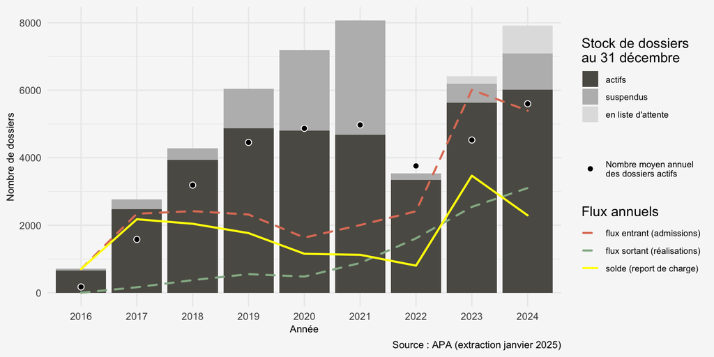

Figure 9: Évolution annuelle du stock des dossiers au 31 décembre (selon l’évolution des flux entrants et sortants)

Enfin, si le ratio entre les flux sortants (réalisations) et entrants (admissions) s’est amélioré par rapport à 2023 - les sorties du parcours représentant 58% des admissions (contre 42% en 2023) -, il varie néanmoins d’une catégorie de public à l’autre ( Table 3). D’un côté, les entrées et sorties du public non-prioritaire sont à l’équilibre (ratio = 1.02) en raison de la mise en place de la liste d’attente, mais aussi de parcours plus rapide des personnes étrangères recourant au parcours d’accueil dans le cadre de la demande de nationalité. Trois quart (76%) d’entre elleux ont en effet le niveau linguistique requis, ce qui accélère fortement la durée de parcours (cf. infra : chapitre 4). De l’autre, les parcours réalisés du public prioritaire représentent seulement un tiers (32%) des admissions. Autrement dit, **pour chaque primo-arrivant·e obligé·e sortant en 2024, trois nouveaux·elles bénéficiaires prioritaires sont admis·es.**

A cet égard, en prenant la moyenne des sorties mensuelles tous publics confondus (301) et des entrées mensuelles du public prioritaire (287) sur les trois derniers mois de 2024, il ne resterait que 14 places disponibles pour les personnes en liste d’attente. Ainsi, si le rythme des admissions et des sorties de la fin 2024 se poursuit, la liste d’attente ne devrait pas diminuer rapidement. Ceci laisse à penser que le dispositif tend vers une saturation de public prioritaire, et par extension à une plus forte exclusion du public non prioritaire dans les prochaines années, quand bien même le nombre de personnes étrangères venant pour la nationalité devrait diminuer vu qu’une grande partie d’entre elleux aura à terme déjà réalisé le parcours d’accueil en tant que primo-arrivant soumis à l’obligation.

Entrées

Sorties

Solde

Ratio (%)*

Personne étrangère

1 099

1 126

−27

102

Primo-arrivant ayant droit

907

927

−20

102

Primo-arrivant obligé

3 334

1 062

2 272

32

Total

5 340

3 115

2 225

58

: le ratio des réalisations sur les admissions (100% = équilibre des flux entrants et sortants)

- : le ratio des réalisations sur les admissions (100% = équilibre des flux entrants et sortants)

Table 3: Tableau synthétique des flux en 2024 selon les catégories de bénéficiaires

## 3.4 Ressources humaines et charge de travail

Cette saturation depuis la fin 2023 a inévitablement augmenté la pression sur les Bureaux d’accueil. Cependant, bien que le nombre de dossiers actifs au 31 décembre 2024 était le plus élevé jamais atteint (6.013), la charge de travail s’est légèrement réduite en raison d’un renforcement et d’une réorganisation des ressources humaines dans les différents Bapas en 2024[^16].

- Au niveau de l’accompagnement social (+ 12 ETP par rapport à 2023), nous pouvons estimer un nombre de **120 dossiers actifs par ETP effectif dédié à l’accompagnement social** au 31 décembre 2024, soit une diminution d’environ 20% par rapport à l’année dernière (150 dossiers actifs par ETP). En y ajoutant les dossiers suspendus, ce chiffre s’élève 140 dossiers potentiellement actifs par ETP (contre 160 dossiers actifs par ETP en 2023)[^17].
- Au niveau des formations à la citoyenneté, environ **510 heures de FOCI par formateur·trice** ont été données en 2024. Ce qui représente par formateur·trice 8,5 FOCI de 60h par an ou 10 FOCI de 50h[^18].

Si ces derniers chiffres donnent une indication sur la charge de travail la plus visible des formateur·trices à la citoyenneté et des accompagnateur·trices sociales, cet indicateur ne révèle toutefois qu’une part de leur charge de travail respective et de la charge globale d’un Bapa. D’autant plus que les tâches organisationnelles annexes ont fortement augmentées suite aux réformes législatives de 2022, en particulier les tâches administratives associées à la contrainte des recours au dispositif, notamment lié à la production d’attestations[^19]. C’est précisément **l’inflation de la charge administrative** que nous exposons dans la fin de ce deuxième chapitre sur base des rapports d’activités 2024 des trois bureaux d’accueil.

### 3.4.1 L’accueil : un screening du public non-prioritaire

Il convient tout d’abord de mettre en lumière le travail réalisé à l’accueil par les Bapas. Bien que cette activité ne soit pas quantifiée dans l’outil APA, les Bapas tiennent néanmoins des registres d’accueil qui permettent d’en mesurer partiellement l’ampleur. En 2024, **8.673 personnes**[^20] **personnes ont été reçues dans les locaux** des Bapas. Parmi elles, une partie a été admise dans le parcours d’accueil au cours de l’année, tandis que l’autre ne l’a pas été, pour des raisons diverses : **inscription sur liste d’attente**, **absence de nécessité ou de pertinence** à suivre un parcours, ou **non-respect des conditions d’admissibilité** (devenu un cas marginal).

Il est important de souligner que ces chiffres sont vraisemblablement des sous-estimations. D’une part, ils n’incluent pas les nombreux échanges téléphoniques ; d’autre part, les pratiques de recensement dans les registres d’accueil varient d’un opérateur à l’autre. Par exemple, Convivial précise que les orientations ne sont pas systématiquement enregistrées, afin de limiter la charge de travail[^22]. Bien que cette charge à l’accueil soit réelle et mobilise des ressources humaines importantes, elle ne peut pas être sujet à une analyse approfondie par le manque de données.

### 3.4.2 Liste d’attente : une logistique complexe

Bien que la mise en place des listes d’attente visait à réguler le flux de nouvelles admissions, elle a néanmoins généré **une charge de travail de gestion importante** pour les opérateurs. En effet, la liste d’attente multiplie les aller-retours avec les bénéficiaires. La durée de la liste d’attente est fixée à 3 mois, période pendant laquelle le ou la bénéficiaire ne peut s’inscrire dans un autre Bapa. Une fois ce délai écoulé, la personne non-prioritaire peut se représenter dans son Bapa de référence. Deux cas de figure se présentent alors : soit elle peut entamer son parcours d’accueil, soit le délai d’attente est prolongé de trois mois supplémentaires si l’opérateur reste saturé. Si le ou la bénéficiaire ne se manifeste pas à l’issue de cette période, iel pourra alors s’inscrire dans un autre Bapa. Dans la pratique, ce système engendre toutefois des situations complexes : bénéficiaires tentant de s’inscrire ailleurs alors qu’iels sont déjà en liste d’attente, retours multiples, incompréhensions, frustrations, etc.

Depuis décembre 2023, on estime à **2.223 le nombre total de personnes étrangères ayant été inscrites sur une liste d’attente** dans l’un des Bapas[^23], soit l’**équivalent de la** **capacité maximale d’un Bapa de catégorie IV.**

Parmi ces personnes étrangères :

- 37% sont en liste d’attente au 31 décembre 2024 ;
- 34% ne se sont pas représentées après leur mise en attente ;
- 29% ont pu être admises dans le dispositif au 31 décembre 2024.

Les accueillant·es ou travailleur·euses sociaux·ales sont confronté·es à une double exigence : sensibiliser sur le fonctionnement de la liste d’attente et gérer l’agacement voire même l’agressivité[^24] de certain·es bénéficiaires. La plupart des personnes étrangères venant pour des démarches administratives telles que le maintien du RIS, le renouvellement du titre de séjour, parfois soumises à des échéances précises, comme la demande de nationalité, se retrouve insatisfaites lors de mise en liste d’attente. Dans un Bapas, on explique avoir formé son équipe à la gestion de conflits[^25]. Dans un autre, on expose le problème des listes d’attentes qui se rallongent : “*La gestion de personnes sur liste d’attente, à qui nous ne pouvons même pas communiquer un délai d’attente raisonnable (aujourd’hui estimé à plus d’un an) est un réel problème, nécessitant une solution urgente*”[^26] . Par ailleurs, ce public peut présenter des besoins sociaux importants, parfois plus complexes que ceux du public prioritaire.

### 3.4.3 Les suspensions : une charge invisible

Plusieurs problématiques sont soulevées par les Bapas concernant les suspensions. Tout d’abord, les opérateurs font face à la **multiplication des demandes de suspension**, en particulier lorsqu’il s’agit de raisons professionnelles, en raison de délais de suspension initialement trop courts. Afin de répondre à cette problématique, la durée de suspension pour ce motif a été étendue de 3 à 6 mois au cours de l’année 2025.

A cela s’ajoutent des **difficultés de communication ou d’échange avec certaines administrations communales**, souvent peu réactives lorsqu’il s’agit de valider les suspensions. Cette lenteur administrative complique la gestion des dossiers, comme l’illustre un des Bapas :

> “*Dans une majorité de cas, la demande de suspension est validée dans un délai assez long par la commune du domicile de la personne primo-arrivante. Pour illustrer cette difficulté, nous avons régulièrement des demandes de prolongation de suspension à introduire, alors que la période précédente n’a pas encore été validée.*” (Rapport d’activités 2024, VIA, p.10)

Les Bapas relèvent également des **limites techniques** qui compliquent le suivi des dossiers. Par exemple, à la fin du délai de suspension :

> ” *Il n’y a pas de notification ou de réactivation automatique du dossier après la période de suspension. Or, le compteur lié au délai pour remplir ses devoirs en termes d’obligation de suivre le Parcours d’accueil se remet en route*.” (Rapport d’activités 2024, VIA, p.10).

Ces problématiques entrainent une charge administrative accrue pour les accompagnateur·trices sociaux·ales, au détriment du temps consacré à l’accompagnement social[^27].

En ce qui concerne les motifs de suspensions, le CBAI n’a pas eu cette année accès aux données. Cependant, VIA a fourni des données dans son rapport des données. Leurs chiffres montrent que parmi les motifs connus de suspension[^28], celles liés à des formations, à des obligations familiales ou professionnelles sont relativement équiréparties et représentent près des trois quarts des cas. Les motifs de santé ou autres restent plus marginaux.

# 4 PROFILS DES BÉNÉFICIAIRES ADMIS·ES/INSCRIT·ES

Nous présenterons dans cette partie les données uniquement dans une **logique de flux**, à savoir l’ensemble des personnes nouvellement admises[^29]. **En 2024, 5.352 bénéficiaires ont été admis·es**, dont **62,5% étaient des primo-arrivant·es et 37,5% des personnes étrangères**.

Nous décrivons le **profil socio-démographique des personnes inscrites** pour la première fois en 2024 en suivant une **approche comparative** et **évolutive** avec les années précédentes. Nous ventilons, par ailleurs, les indicateurs selon la pertinence, par catégorie administrative et par genre des bénéficiaires (*cf. supra*). **Les données sur le profil des bénéficiaires sont déclaratives** et sont tirées des bilans sociaux[^30]. La grande quantité d’inconnus est due à des bilans sociaux non encore réalisés.

## 4.1 Situation sociodémographique : genre, âge et composition du ménage

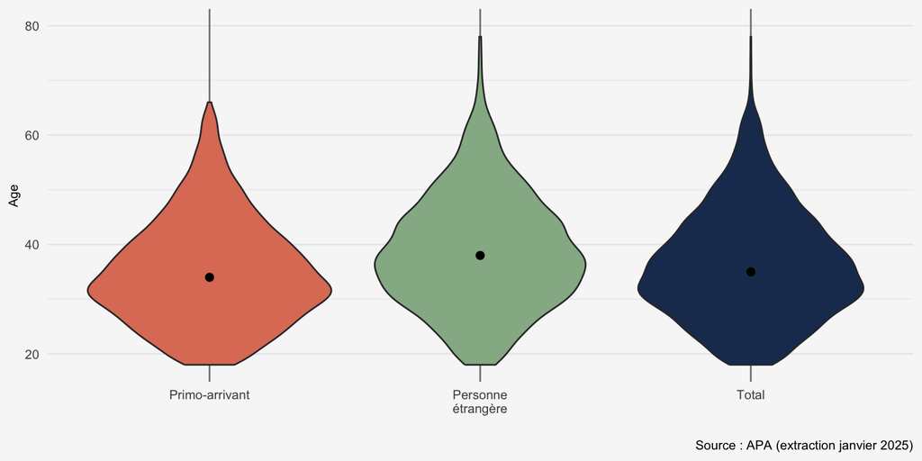

Figure 10: Répartition du public admis selon l’âge et la catégorie de public.

Ensuite, l’évolution de la composition des ménages montre des répartitions très semblables à celles des dernières années. Les **bénéficiaires vivant en couple avec enfant(s) constituent toujours la catégorie la plus représentée**, comptant un tiers des admissions, bien que leur part ait diminué. Cependant, cette diminution est certainement liée à l’importante proportion d’inconnus[^32].

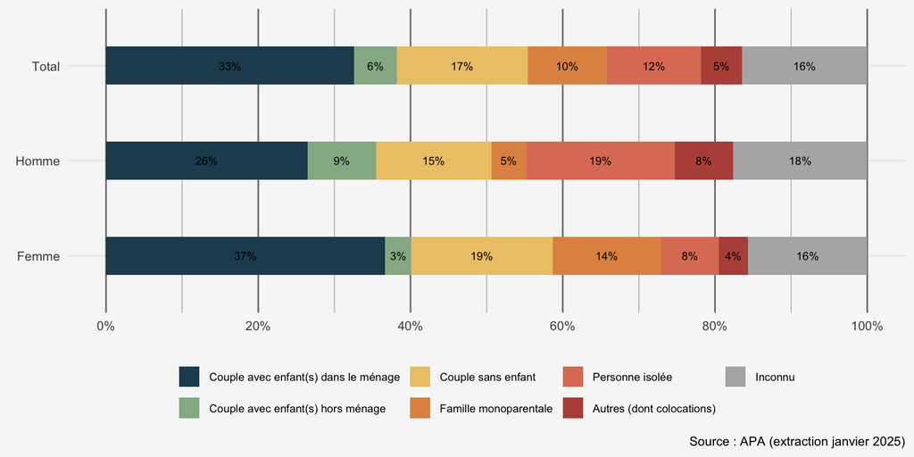

Figure 11: Répartition du public admis selon la composition du ménage et le genre.

Si l’on compare les situations des ménages selon les deux types de bénéficiaires, des différences ressortent également. Sachant que les primo-arrivant·es ont plus de données inconnues (20%), iels sont davantage représenté·es en couple sans enfants (22%) que les personnes étrangères. Ces dernières sont plus fréquemment en couple avec enfant(s) dans le ménage (37%), en tant que personnes isolées (22%) ou en situation de monoparentalité (17%). Ces différences peuvent s’expliquer par l’écart de temporalité de recours dans la carrière d’installation de ces deux catégories administratives. Si les primo-arrivant·es sont obligé·es de suivre le parcours dès le début de leur installation, il est plus probable que la question de la parentalité - ou la présence d’enfants dans le ménage - n’intervienne que plus tard. À l’inverse les personnes étrangères - en particulier celles installées depuis plus de 3 ans - sont plus susceptibles d’avoir des configurations familiales qui évoluent (avec naissance d’enfants ou monoparentalité).

## 4.2 Nationalité : régions et pays d’origine

**En 2024, 98 % des personnes admises au Parcours d’accueil proviennent de pays hors de l’UE27+.** Trois grandes régions d’origine concentrent la majorité des bénéficiaires admis (74%) : **l’Afrique du Nord (27 %), l’Asie occidentale (25 %) et l’Afrique subsaharienne (22 %)** (Figure 12). Si ces trois régions représentaient déjà la majorité du public en 2023, on remarque l’augmentation des personnes originaires de pays d’Afrique subsaharienne (+4pp.), au détriment des bénéficiaires d’Afrique du Nord (-2pp.) et d’Asie occidentale (-1pp). Par ailleurs, la part des bénéficiaires issus d’Asie orientale (5%) et d’Amérique latine ou des Caraïbes (9%) est également en hausse (respectivement de 2pp), tandis que celle des ressortissant·es européen·nes continue à baisser (-3pp).

Les personnes issues de pays d’Afrique du Nord sont majoritairement marocaines (82 %), faisant du **Maroc la première nationalité** **pour la troisième année consécutive**, avec près d’**un quart du public total** (23 %). Parmi les pays de l’Asie occidentale, la Syrie demeure en tête (43 %), suivie par l’Inde (10 %) et la Turquie (9 %), ce dernier pays étant en nette progression tandis que la part d’Indien·nes reculent. En Afrique subsaharienne, les nationalités les plus fréquentes sont celle de la Guinée (26 %), de la République démocratique du Congo (15 %), du Cameroun (13 %) et, en hausse cette année, du Burundi (11%). Enfin, pour les bénéficiaires provenant d’Amérique latine ou des Caraïbes, les Brésilien·nes sont les plus nombreux·euses (60%), suivis par les Colombien·nes (11%). Si la répartition par grands ensembles régionaux reste similaire à celle de l’année précédente, des variations apparaissent dans le classement des dix nationalités les plus représentées.

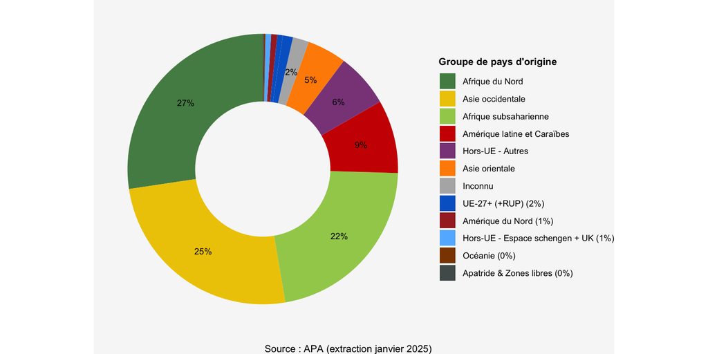

Figure 12: Répartition du public admis selon le groupe de nationalité.

**Le top dix des premières nationalités du public admis en 2024** (tableau ci-dessous) montre deux nationalités dominantes dans le parcours : **la marocaine (22 %) et syrienne** (**11 %** - une part probablement sous-estimée due aux inconnus). Ensemble, elles représentent un tiers du public, comme pour 2023, et leur répartition est homogène entre catégorie de public. Les personnes originaires de Guinée arrivent en troisième position, avec une progression depuis 2022 (Figure 13).

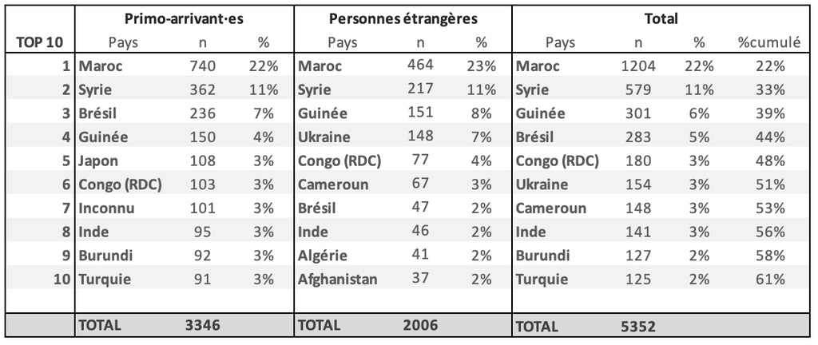

Top 10 des nationalités plus représentées parmi les admis par catégorie de public.

L’un des effets soulevés des réformes législatives de 2022 a été la **diversification des origines**[^33], notamment avec **l’apparition de nouvelles nationalités et le renforcement de certaines déjà présentes**. Parmi les cas les plus notables figurent l’apparition, principalement chez les primo-arrivant·es obligés, des **nationalités brésilienne et japonaise** - déjà mentionné dans le précédent monitoring. En 2024, les Brésilien·nes constituent la troisième nationalité représentée du public prioritaire (soit 7%) et les Japonnais·es occupent la cinquième avec 3%.

Cette année, Cameroun (3%) et l’Algérie (2%), font également leur entrée dans le top 10 des personnes étrangères. On remarque d’ailleurs une tendance à la hausse des bénéficiaires originaires de pays francophones. On note également une **augmentation progressive de la part des bénéficiaires ukrainien·nes depuis 2021,** désormais en quatrième position parmi les personnes étrangères. Il s’agit souvent des ancien·nes bénéficiaires BPTU souhaitant prolonger leur apprentissage du français. En revanche, la part des personnes de nationalité indienne poursuit sa baisse (-2pp). En deux ans, leur représentation a chuté de 10 points de pourcentage, et depuis 2019, 18pp. Avant l’obligation, les bénéficiaires indien·nes, notamment ceulleux habitant à Evere, étaient très souvent contraint·es de faire le Parcours d’accueil (voir infra), après obligation, leur part est ré-équilibrée (voir infra).

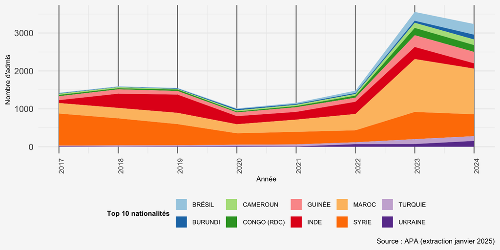

Figure 13: Évolution des 10 premières nationalités du public admis de 2024.

## 4.3 Situation socio-professionnelle : revenus et plus hauts diplômes obtenus

Les bénéficiaires des BAPAs font face à une grande précarité, lié notamment à leur situation socioprofessionnelle. Parmi les personnes admis·es[^34] en 2024, **46 % sont inactives** : 16% sont allocataires du RIS et 30% ne perçoivent pas de revenus.

L’évolution des situations socio-professionnelles des publics admis depuis 2017 (Figure 14) montre une tendance à la **concentration autour de deux situations opposées** : **les personnes en emploi et celles sans revenus**. Cette évolution s’explique par la diminution de la proportion d’allocataires RIS, qui décroit de 17 pp. en cinq ans, accompagnée par la progression des personnes en emploi, bien que plus lente et avec l’exception de 2024. La diminution continue du nombre d’allocataires RIS s’explique par l’augmentation des bénéficiaires en regroupement familial, en particulier des femmes (15% perçoivent le RIS contre 19% des hommes), souvent exclues des aides sociales et dépendantes financièrement du conjoint.

L’augmentation du nombre de bénéficiaires en emploi soulève de nouvelles problématiques, tant pour les bénéficiaires que pour les Bapas, auparavant moins fréquentes. Au Bapa Convivial, on donne l’exemple des bénéficiaires brésilien·nes, souvent en emploi :

> *“Ce public spécifique nous pose souvent soucis car il travaille souvent, et a donc du mal à être disponible pour suivre les formations et pouvoir finir le parcours dans les 18 mois impartis (pas de possibilité de suspension pour raisons de travail, pas de possibilité de congé éducation). Au sein de ce public brésilien, nous rencontrons un certain nombre de personnes sous statut d’indépendant pour lesquels s’absenter pour les formations engendre par conséquent une perte de revenus.”* (Rapport d’activités 2024, Convivial, p.16).

Par conséquent, les Bapas ont dû adapter leur offre afin de répondre aux besoins spécifiques des publics en emploi ou en formation[^35], notamment en développant l’offre de formations citoyennes en soirée (cf. infra). Toutefois, ces formations restent marginales, en raison de nombreuses difficultés à les organiser[^36].

Enfin, bien que le public sans revenus demeure le plus représenté, il enregistre une diminution pour la deuxième année consécutive, avec une baisse de 7pp. en deux ans.

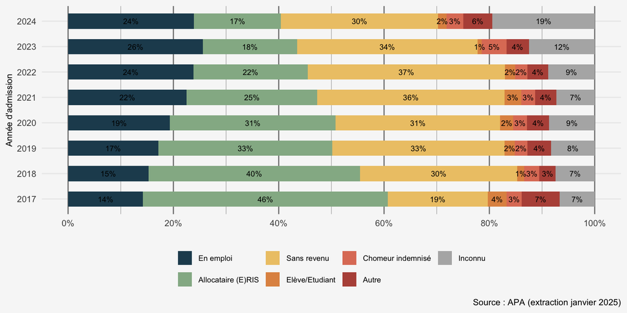

Figure 14: Évolution des situations socio-profesionnelles du public admis (2017-2024).

Au sein du **public prioritaire**, **34% ne perçoivent aucun revenu**, contre 21% en emploi et 14% allocataires RIS. Cette répartition s’explique notamment par leur plus grande représentation en situation de regroupement familial (74% d’entre eux·elles) et probablement, par leur arrivée relativement récente. A ce sujet, au BAPA VIA, on témoigne :

> “*La situation financière des personnes primo-arrivantes, et essentiellement des femmes, sans revenus, parfois en situation précaire, peut avoir un impact sur le déroulement du Parcours d’accueil (une stabilisation des besoins vitaux est nécessaire avant d’entamer réellement le Parcours)*.” (Rapport d’activités 2024, VIA, p. 22).

Au BAPA Convivial, on explique rencontrer plus spécifiquement des situations de personnes sans revenus et de sans-abrisme, pour lesquelles une adaptation du travail est également nécessaire avant de pouvoir proposer une formation[^37].

Concernant les **personnes étrangères**, la répartition entre les trois principales situations socio-profesionnelles est **plus équilibrées** : 29% sont en emploi, 22% sans revenus, et 21% sont allocataires RIS. Ces dernier·ères sont parfois amenées à s’inscrire au Parcours d’accueil sous la contrainte du CPAS pour pouvoir maintenir ou percevoir le RIS.

En termes de genre, les disparités entre hommes et femmes se creusent (Figure 15). **Les femmes sont majoritairement sans revenus** (41% contre 14% des hommes), tandis que **les hommes sont plus souvent en emploi** (34% contre 17% des femmes). Comme le mentionnent les Bapas, la précarité augmente chez les femmes. Si certaines choisissent de rester au foyer, d’autres se retrouvent dépendantes de leur conjoint·e en raison de leur statut de résidence, voire totalement privées de ressources, allant jusqu’à des situations de sans-abrisme[^38].

Toutefois, il convient aussi de nuancer la situation des personnes en emploi, ce qui n’équivaut pas à une situation socio-économique pérenne et stable ; il s’agit souvent de contrats précaires tels que des emplois « flexibles », des intérims, des emplois à temps partiels ou des CDD. En outre, le travail non déclaré, par définition non recensé, échappe à ces statistiques.

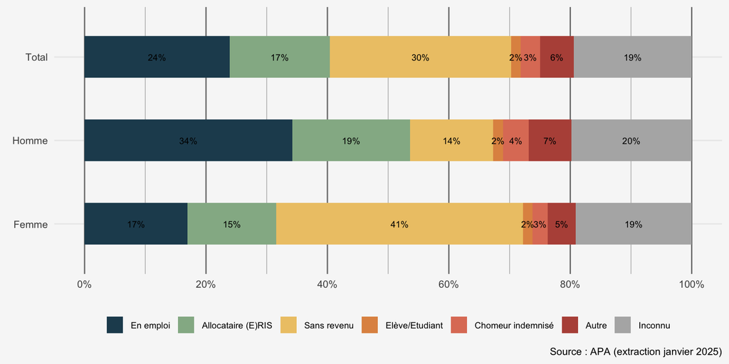

Figure 15: Répartition des situations socio-profesionnelles du public admis selon le genre

En ce qui concerne le niveau d’étude, nous retrouvons une répartition similaire à l’année dernière (Figure 16), même s’il y a une croissance de 6pp des inconnus. Pour rappel, l’année 2023 avait été marquée par une diminution des publics plus diplômés au détriment du public “infra-diplômé”[^39] en raison de la diversification du public suite aux réformes de 2022, notamment avec l’arrivée des personnes étrangères moins diplômées. Cette année les bénéficiaires détenant **au moins un diplôme du CESS (ou équivalent) restent majoritaires** (46%) mais le **public “infra-diplômé” représente plus d’un tiers du public** (36%). Au BAPA VIA, on nuance les chiffres des diplômes avec les questions de la langue :

> “*Même lorsqu’il ou elle dispose d’un diplôme de l’enseignement primaire, de nombreux bénéficiaires ne semblent pas avoir acquis les compétences du CEB et/ou ne maitrisent en tout cas pas l’alphabet latin*.” (Rapport d’activités 2024, VIA, p.23).

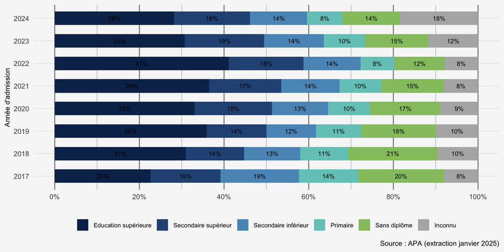

Figure 16: Évolution du plus haut diplôme obtenu à l’étranger ou en Belgique (2017-2024).

Si on analyse cet indicateur selon les catégories de bénéficiaires (Figure 17), on constate que **les personnes étrangères restent plus souvent “infra-diplômé·es”,** représentant 42% de ce public. En revanche, près de **la moitié des primo-arrivant·es sont détenteur·trices au minimum d’un diplôme du CESS**, sachant que le taux d’inconnus est plus important pour ces dernier·ères. En excluant les inconnus, iels compteraient 60% du public.

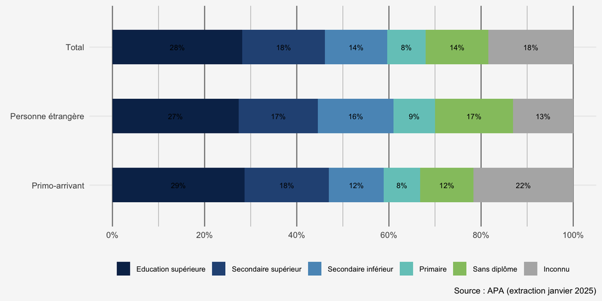

Figure 17: Répartition du plus haut diplôme obtenu à l’étranger ou en Belgique selon la catégorie de bénéficiaire

Des différences de genre existent également, **les femmes sont plus diplômées que les hommes.** Cette tendance est particulièrement marquée dans l’enseignement supérieur, où 31% des femmes sont titulaires d’un diplôme du supérieur contre 24% des hommes. A l’inverse, ces derniers sont plus représentés parmi les diplômes du primaire et le secondaire inférieur (26% contre 19% des femmes).

## 4.4 Situation socio-juridique : titres et motifs de séjour

L’évolution des motifs de séjour montre **une croissance soutenue des raisons liés au regroupement familial**, **en dépit des protections internationales (réfugiés et protections subsidiaires) qui ne cessent de diminuer jusqu’en 2023** et qui se stabilisent en 2024. En 2024, ces deux motifs représentent toujours la majorité du public admis des Bapas, soit 80% ( Figure 18). Ces évolutions doivent se comprendre dans le contexte migratoire national, où le regroupement familial est devenu la principale voie d’accès au territoire[^40] et dans le contexte d’obligation. Par ailleurs, nous observons que depuis 2022, la part des motifs de séjour pour des raisons lié au travail ou aux études a chutée, devenant minoritaires (2%).

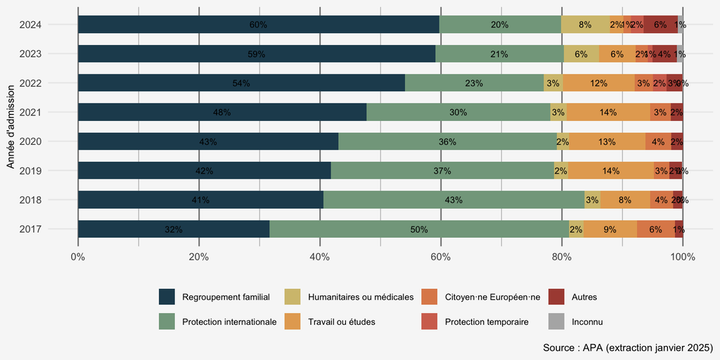

Figure 18: Évolution du public admis selon les motifs de délivrance de séjour (2017-2024).

En ce qui concerne les catégories de bénéficiaires, les **motifs de séjour des primo-arrivant·es se concentrent autour de quatre raisons principales** : 64 % par regroupement familial, 18 % au titre de la protection internationale, 10 % pour raisons médicales ou humanitaires, et 7 % pour d’autres motifs. À l’inverse, **les personnes étrangères présentent des motifs de séjour plus diversifiés**, bien que la majorité concerne le regroupement familial (52 %) et la protection internationale (24 %). Les autres motifs relèvent principalement d’exemptions prévues par la législation, comme le statut de citoyen·ne européen·ne, la protection temporaire, le travail ou les études.

Enfin, en termes de genre, de grandes différences de répartition apparaissent, même si les deux principaux motifs de séjour (regroupement familial et protection internationale) représentent ensemble 80 % des cas pour les hommes comme pour les femmes. **La majorité des femmes arrivent via le regroupement familial (69 %)**, tandis que seules 12 % sont bénéficiaires de la protection internationale. À l’inverse, **chez les hommes, la répartition est plus équilibrée** : 46 % pour le regroupement familial et 33 % au titre de la protection internationale.

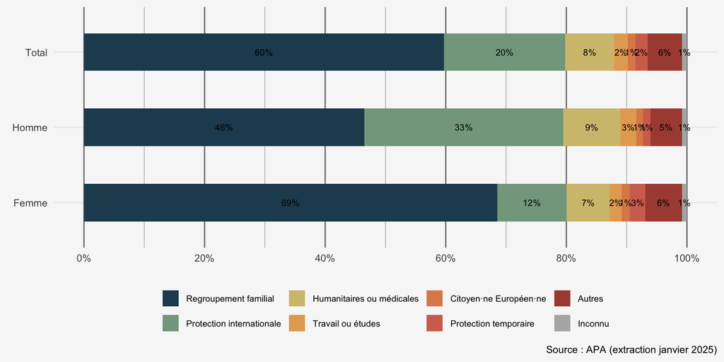

Figure 19: Public admis en 2024 selon les motifs de délivrance de séjour par genre.

Pour l’analyse des cartes de séjour, nous ferons la distinction entre les **séjours limités** et les **séjours illimités**[^41]. La durée du séjour constitue un enjeu central en matière de **précarité administrative**, ainsi que dans les conditions d’accès et de suivi du Parcours d’accueil.

Après une année exceptionnelle (2023), durant laquelle plus de la moitié du public admis disposait d’un séjour illimité (environ 53 %), la tendance s’est inversée en 2024. En effet, avec la hausse des cartes A (+ 8 pp.) et des cartes orange (+ 4 pp.), les **séjours limités deviennent majoritaires, représentant désormais 55 % du public** (+ 8 pp.). La progression des cartes A s’explique, notamment, parce que les personnes en regroupement familial avec une personne de nationalité extra-européenne reçoivent désormais une carte A au lieu de la carte F (Rapport d’activités 2024, VIA, p.25).

En ce qui concerne les **séjours illimités**, la part des **cartes B, détenues uniquement par des personnes étrangères**, se voit divisée par deux atteignant le niveau le plus bas depuis plusieurs années. Les **cartes F et F+** diminuent également, mais de manière plus modérée. Ces dernières sont davantage représentées par des personnes étrangères. Ce tournant dans les tendances est à mettre en lien avec la diversification des publics.

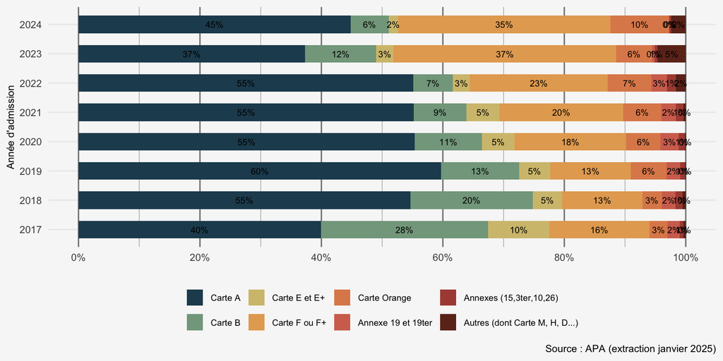

Figure 20: Évolution du public admis selon la carte de séjour (2017-2024).

A ce propos, deux bureaux d’accueil soulèvent **deux principales difficultés,** dans leur rapport d’activités, lors de la mise en œuvre de l’obligation avec les personnes disposant de **séjours limités** : **les interruptions ou renouvellements des titres de séjour** les amènent parfois à devoir faire un travail de réorientation vers des associations juridiques, mais aussi entraînent **des planifications complexes de formations** lorsque le titre de séjour expire dans un court délai[^42].

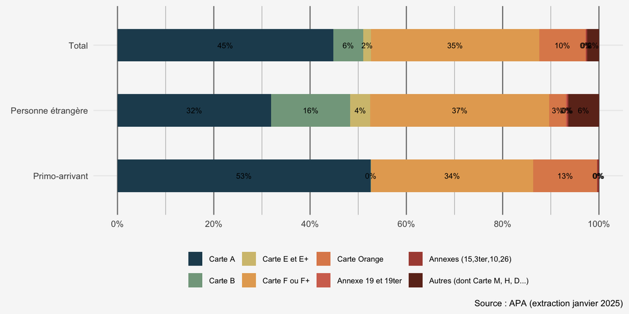

Figure 21: Public admis en 2024 selon le type de carte de séjour par catégorie de bénéficiaire.

## 4.5 Géographie résidentielle : communes de résidence

En 2023, nous avions soulevé une “**décentralisation spatiale**” des communes de résidence des bénéficiaires admis·es, une tendance qui se poursuit en 2024. La concentration du public dans les cinq communes d’implantation reste la même qu’en 2023 : **55% des bénéficiaires y résident,** contre 60% en moyenne entre 2017 et 2022 pour ces mêmes communes[^43]. Cette baisse s’explique notamment par le **renforcement des communes de deuxième couronne**, en particulier à Uccle (*+3 % par rapport à la période 2017-2022*), à Auderghem, Ganshoren et Woluwe-Saint-Pierre. Ces évolutions illustrent l’impact de l’entrée en vigueur de l’obligation, ces communes n’orientaient que très rarement des personnes vers le Parcours d’accueil avant l’obligation. Aujourd’hui, elles sont en augmentation dans le dispositif avec une représentation en majorité de primo-arrivant·es.

| Commune de résidence | Primo-arrivant·es Effectif | Primo-arrivant·es Part (%) | Personnes étrangères Effectif | Personnes étrangères Part (%) | Total Effectif | Total Part (%) |
| --- | --- | --- | --- | --- | --- | --- |
| Total | 3 334 | 100% | 2 006 | 100% | 5 340 | 100% |
| Anderlecht | 456 | 13.7% | 326 | 16.3% | 782 | 14.6% |
| Bruxelles-Ville | 457 | 13.7% | 293 | 14.6% | 750 | 14% |
| Molenbeek-Saint-Jean | 352 | 10.6% | 241 | 12% | 593 | 11.1% |
| Schaerbeek | 230 | 6.9% | 266 | 13.3% | 496 | 9.3% |
| Ixelles | 287 | 8.6% | 116 | 5.8% | 403 | 7.5% |
| Forest | 169 | 5.1% | 134 | 6.7% | 303 | 5.7% |
| Uccle | 182 | 5.5% | 79 | 3.9% | 261 | 4.9% |
| Jette | 139 | 4.2% | 102 | 5.1% | 241 | 4.5% |
| Saint-Josse-Ten-Noode | 187 | 5.6% | 49 | 2.4% | 236 | 4.4% |
| Saint-Gilles | 121 | 3.6% | 91 | 4.5% | 212 | 4% |
| Etterbeek | 123 | 3.7% | 53 | 2.6% | 176 | 3.3% |
| Koekelberg | 132 | 4% | 40 | 2% | 172 | 3.2% |
| Woluwe-Saint-Pierre | 129 | 3.9% | 19 | 0.9% | 148 | 2.8% |
| Auderghem | 118 | 3.5% | 14 | 0.7% | 132 | 2.5% |
| Evere | 42 | 1.3% | 65 | 3.2% | 107 | 2% |
| Ganshoren | 79 | 2.4% | 26 | 1.3% | 105 | 2% |
| Woluwe-Saint-Lambert | 56 | 1.7% | 46 | 2.3% | 102 | 1.9% |
| Berchem-Sainte-Agathe | 42 | 1.3% | 26 | 1.3% | 68 | 1.3% |
| Watermael-Boitsfort | 33 | 1% | 20 | 1% | 53 | 1% |

Source : APA (extraction janvier 2025)

Table 4: Public admis en 2024 selon la commune de résidence et la catégorie de bénéficiaire.

Enfin, pour la deuxième année consécutive, **la commune d’Evere connaît une baisse significative**, avec une diminution de 4 pp. par rapport à la période 2016-2022. Le nombre de bénéficiaires d’Evere atteigne aujourd’hui **l’un de ses niveaux les plus bas**. Cette chute s’explique par une **sur-représentation historique** de cette commune, qui n’est pourtant pas une commune d’implantation. Avant les réformes de 2022**,** Evere orientait systémiquement les personnes devant renouveler leur séjour vers les Bapas, sans que cela ne corresponde au flux réel de primo-arrivant·es. Aujourd’hui, la majorité des bénéficiaires d’Evere relèvent davantage du **public “personnes étrangères”** que celui des primo-arrivant·es. Des tendances similaires sont observées à Bruxelles-Ville et Schaerbeek, ce qui peut s’expliquer par la présence d’une implantation sur leur territoire.

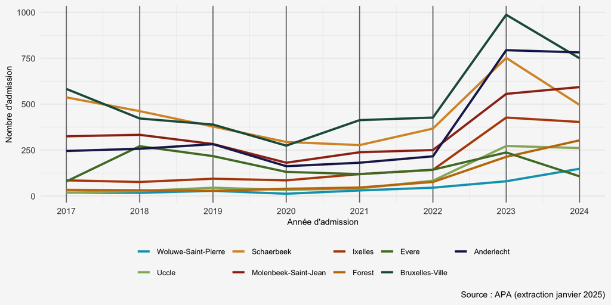

Figure 22: Évolution du public admis selon la commune de résidence (2017-2024).

**Une analyse spatiale infra-communale avant et après les réformes de 2022**

Comme mentionné dans la méthodologie, depuis 2023, l’APA n’encode plus automatiquement les secteurs statistiques, et en 2024, nous n’avons pas eu accès aux adresses, rendant impossible une analyse spatiale infra-communale pour 2024. Toutefois, nous avons pu exploiter les données de juin 2024 mobilisées pour la recherche sur les effets des reformes de 2022. Il nous semble pertinent d’en présenter ici quelques résultats.

Les cartes ci-dessous illustrent les **coefficients de spécificité** des quartiers où se trouvent des personnes étrangères et primo-arrivant·es après les réformes de 2022, comparés à la période antérieure. Attention, contrairement au reste de ce chapitre, les personnes étrangères sont ici définies comme les bénéficiaires vivant en Belgique depuis plus de trois ans.

La représentation par quartier des bénéficiaires révèle également un renforcement des personnes résidant dans la seconde couronne – des communes qui orientaient moins vers les Bapas avant l’obligation, mais aussi plus aisées (figure ci-dessous). On observe toutefois une différence entre les deux publics :

- **les Primo-arrivant·es obligé·es** **sont davantage représenté·es dans les quartiers aisés du sud-est de la Région** (*Etterbeek, Ixelles, Saint-Gilles, Uccle),* *c*e qui renforce l’idée que l’obligation attire des profils de primo-arrivant·es qui ne venaient pas spécialement dans le parcours auparavant.
- **les Personnes étrangères sont plus représentées dans les quartiers intermédiaires du nord-ouest.** Cette surreprésentation des personnes étrangères - séjournant depuis plus longtemps en Belgique - dans l’ouest de la RBC peut être mise en parallèle avec les dynamiques résidentielles intra-urbaines déjà mises en évidence ailleurs, notamment des quartiers populaires centraux, jouant un rôle d’accueil pour les populations étrangères issues de pays pauvres ou intermédiaires, vers les quartiers intermédiaires de la deuxième couronne nord-ouest[^45].

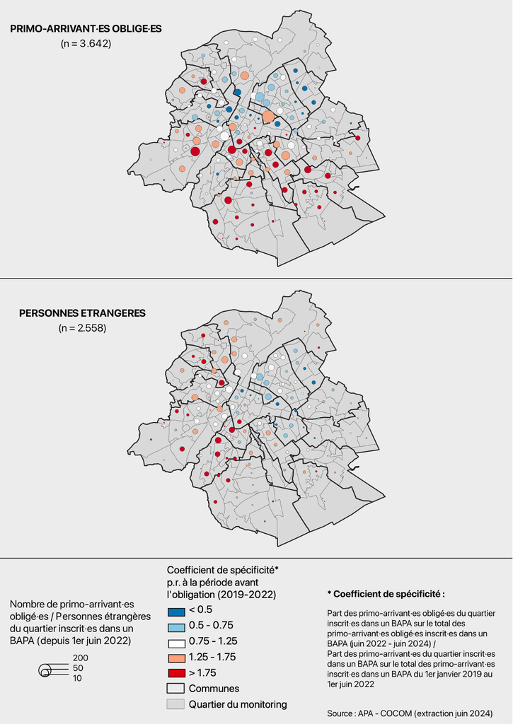

  Spécificité résidentielle des “primo-arrivant·es obligé·es” et des “personnes étrangères” (2022-2024) par rapport à la période pré-réformes (2019-2022)

En conclusion, en 2024, les profils des bénéficiaires affichaient des tendances très similaires à celles de 2023. Les réformes législatives ont amené un public plus diversifié en termes de nationalités mais ont aussi eu un effet de concentration notamment dans les motifs de séjour, les diplômes et les situations socio-profesionnelles. En dernière analyse, ces réformes ont eu tendance à élargir la zone de recrutement des Bapas.

# 5 ACTIONS MISES EN ŒUVRE PAR LES BAPAS

## 5.1 Programme d’accueil

### 5.1.1 Bilan social

Le bilan social (BS) représente une étape cruciale dans le parcours. Il s’agit du premier contact avec un·e assistant·e social·e, moment essentiel pour instaurer une relation de confiance afin d’identifier les besoins et les connaissances du·de la bénéficiaire. Ce temps d’échange doit permettre de définir les objectifs et stratégies à mettre en place dans la suite du parcours. Le bilan social permet en outre d’aider les bénéficiaires à comprendre un ensemble de démarches administratives ainsi que les documents reçus par des administrations, à accéder à certains droits (mutuelle, allocations diverses, etc.), à des services spécialisés (entre autres associatifs), ou encore à rechercher des solutions en cas d’urgence (relais vers des services psychologiques, du logement, de l’aide matérielle…).

En 2024, **4.949 bilans sociaux ont été réalisés**[^46] par les trois Bapas, ce qui représente une baisse de 9% par rapport à 2023. Cette baisse est plus faible que la baisse du flux des admissions en 2024. Toutefois, cela représente plus du double que pour 2022 (+ 120%) et que des standards connus avant les réformes de 2022 (Figure 23). Parmi les bilans sociaux de 2024, **59% correspondent à des primo-arrivant·es et 41% à des personnes étrangères.**

Pour évaluer l’efficacité du parcours à ce stade, nous comparons la part ayant réalisé un bilan social la même année. Parmi les 5.352 personnes admises en 2024, **85 % ont réalisé un bilan social**, soit 4.546 bénéficiaires. Alors qu’en 2023, cet indicateur avait connu sa valeur la plus faible depuis 2017 se situant à 81%, en 2024 cet indicateur atteint la moyenne des six dernières années se situant à 86 %. Cette augmentation est probablement due à la liste d’attente qui a permis d’équilibrer le flux des admissions et un déroulement des parcours dans de meilleures conditions.

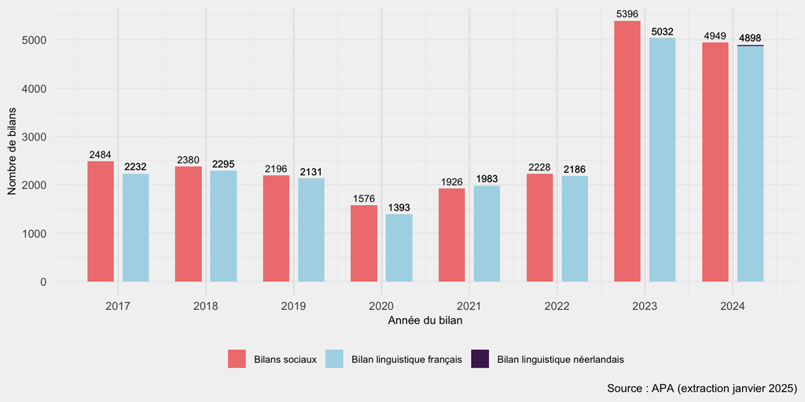

Figure 23: Évolution du nombre de bilans sociaux et linguistiques (2017-2024).

### 5.1.2 Bilan linguistique

Le **bilan linguistique** (BL) est également un moment important pour la suite du parcours. Il sert à évaluer les compétences linguistiques en français ou en néerlandais du·de la bénéficiaire et le·la positionner au sein des différents niveaux de formations (filières et modules), en vue de son inscription à un premier module auprès des opérateurs linguistiques lorsque le niveau pressenti est inférieur au A2 du CECR (Art 13, Arrêté COCOM 2024*)*. Le BL est effectué par les assistant·es sociaux·ales des Bapas si le choix de la langue d’apprentissage est le français et par la Huis van het Nederlands si le choix est le néerlandais.

En ce qui concerne la langue choisie, la quasi-totalité des bénéficiaires - 99% - optent pour le français. S’agissant de la première année du parcours bilingue ces chiffres sont prématurés et risquent d’évoluer dans les années à suivre. Le BAPA VIA apporte toutefois un éclairage complémentaire : les bénéficiaires exprimant dès le départ le souhait de suivre le parcours en néerlandais sont souvent orientés vers BON, qui n’est pas saturé[^47].

En 2024, on dénombre **4.898 bilans linguistiques** réalisés : dont 99,5% (soit 4.875 bilans) dans les trois Bapas et 23 auprès de la Huis van het Nederlands. Pour ces derniers, ce sont les bénéficiaires eux-mêmes qui se chargent de communiquer le résultat aux Bapas pour les encoder dans l’APA.

Parmi les 4.875 bilans linguistiques francophones effectués par les Bapas, **2.548 bénéficiaires,** **soit plus de la moitié (52%) disposaient déjà du niveau linguistique requis (A2)**. Ce taux est identique à celui de 2023, mais reste supérieur de 16 points de pourcentage à celui de 2022, ce qui confirme une tendance à la hausse du nombre de bénéficiaires ayant des connaissances en français. Parmi ces dernier·ères, 89% ont été positionné·es dans un Bapa, dont **15% relevaient de la filière en alphabétisation et 74% relevaient du FLE**. Ensuite, 8% avaient une attestation reconnue, et le reste correspondant à des bilans sociaux sans résultats.

La répartition des bénéficiaires positionnés avec un **niveau de français requis est relativement homogène entre catégories de publics cibles** : 52% sont des personnes étrangères et 48% des primo-arrivant·es. Toutefois, des différences sont soulevées lorsque l’on observe la répartition par filière linguistique. Si les personnes étrangères sont plus nombreuses à avoir été testées en alphabétisation, les primo-arrivant·es ont plus fréquemment un niveau requis en FLE.

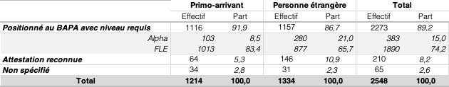

Répartition des bénéficiaires ayant le niveau requis de français en 2024 selon la catégorie de bénéficiaire.

Au total, **2.327 personnes ont été positionnées dans des modules linguistiques** selon une répartition en sous-filière comme suit : **24,4% en Alpha, 6,4% en FLE NAL, 28,3% en FLE A et 39,5% en FLE B.** On dénombre 14 bénéficiaires faisant des cours en dehors du parcours (0,6%) mais c’est une part qui risque d’augmenter dans les années à venir, et enfin 21 bénéficiaires dont la filière d’inscription n’est pas spécifiée (0,9%). En termes de genre, il n’existe pas de différences majeures dans le positionnement linguistique, si ce n’est que les femmes sont plus représentées en FLE B et les hommes légèrement plus en FLE A.

Enfin, si l’on considère l’ensemble des bénéficiaires ayant effectué un bilan linguistique en 2024, ayant le niveau requis ou pas, on observe que **les personnes étrangères relèvent plus souvent de la filière d’alphabétisation**. Si l’on ajoute la filière FLE A cela concerne la moitié des personnes étrangères. Au contraire, **les primo-arrivant·es relèvent plus souvent de la filière FLE B pour près de la moitié du public**.

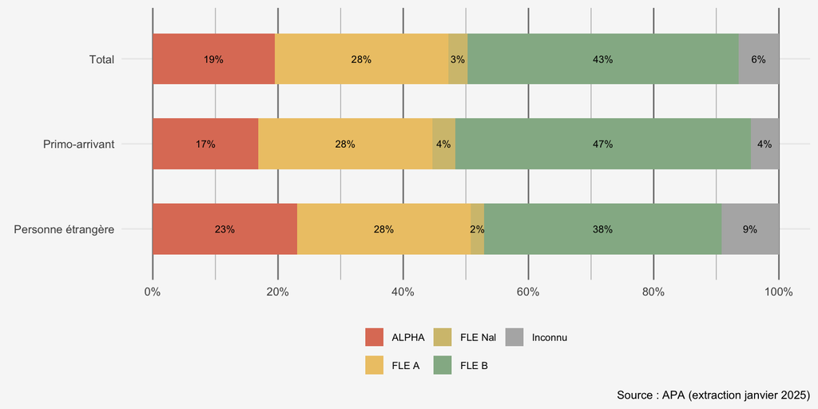

Figure 24: Répartition des bénéficiaires positionnées en 2024 en sous-filières.

Concernant les bilans linguistiques en néerlandais, les Bapas soulignent la bonne collaboration avec het Huis van het Nederlands, bien que le nombre de bénéficaires ayant choisi cette langue reste très limité en 2023. Un Bapa indique notamment que le manque de gratuité dissuade certain·es bénéficaires de suivre des cours en néerlandais[^48]. Ensuite, un des Bapas soulève une limite, il *“arrive encore que des personnes orientées à la Huis van het Nederlands pour y suivre des cours de néerlandais se voient proposer d’intégrer le Parcours néerlandophone de BON. Cela crée des incompréhensions au sein de notre public”* [^49].

### 5.1.3 Information Droits et Devoirs

Les modules « droits et devoirs » (DD) sont en règle générale dispensés par les accompagnateurs·rices sociaux·ales ou par les formateurs·trices. Toutefois, la diversité toujours plus grande des langues proposées (cf. infra) nécessite dans certains cas – en particulier pour les langues rares (Dari, Farsi, Pashto, etc.) – l’intervention d’un·e interprète, que ce soit un·e travailleur·se social·e (au sein des Bapas) ou externe (e.g. : SETIS, Bruxelles Accueil).

La durée d’un module de DD est de 10h. Toutefois, conformément à l’Article 16 de l’Arrêté COCOM de 2024, ce module peut être intégré dans la formation à la citoyenneté pour une durée totale de 60 heures. Ces modules élargis seront abordés dans la partie dédiés aux formations citoyennes.

En 2024, **171 modules DD ont été organisés**, soit une baisse de 36% par rapport à l’année précédente (91 modules en moins). Cette baisse s’explique notamment par une réduction de 15 % du nombre de personnes admises en 2024, mais principalement, par la fusion des modules DD avec les formations citoyennes en modules 60 heures (notamment à Convivial et à BAPA-BXL).

En prenant comme indicateur **la capacité effective -** c’est à dire le **nombre de participant·es** - les Bapas ont accueilli en 2024, **2.908 bénéficiaires dans leurs modules de DD.** Ce chiffre marque une diminution de 38% par rapport à l’année précédente. **La capacité médiane par module est de 18 participant·es,** soit un bénéficiaire de moins qu’en 2023, mais un chiffre nettement supérieur à celui de 2022 (+ 9 participant·es).

En 2024, le **taux de participation diminue** lui aussi, avec un taux de **84 %**. Cette diminution peut s’expliquer par un allongement du délai entre l’inscription et le début de la formation, induit par la saturation suite aux réformes de 2022, ce qui accroîtrait les désistements et les abandons en début de formation.

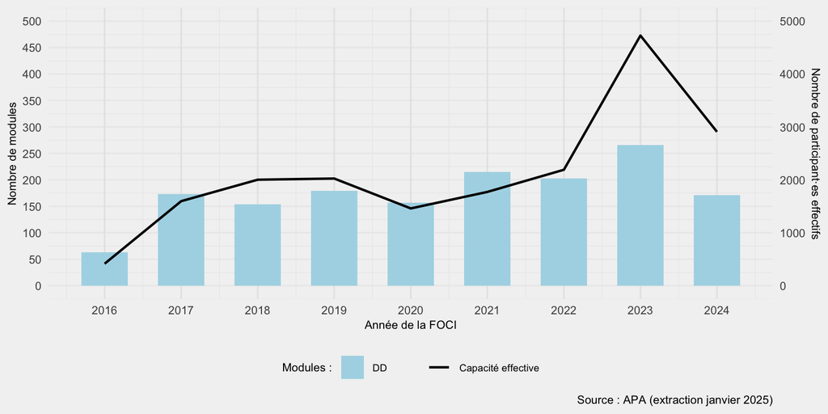

Figure 25: Évolution du nombre de bénéficiaires ayant suivi une DD et du nombre de modules (2017-2024).

En 2024, ces modules sont dispensés dans **20 langues**, mais dans des proportions différentes : **80 % des modules sont réalisés soit en français (35 % dont 5% en français facile), soit dans l’une des langues arabes**[^50] **(30 % des modules pour 36% des participant·es), soit en anglais (15 %)**. Ces trois langues concernent 86 % des participant·es effectif·ves des modules de DD de cette année.

Contrairement aux tendances observées avant les réformes 2022, **les modules en français sont désormais plus nombreux** que ceux dispensés en arabe, ce qui pourrait refléter l’**arrivée plus importante de bénéficiaires maîtrisant déjà le français**. Viennent ensuite l’espagnol et le russe (4 % chacune) et 10 autres langues représentant chacune entre 0 et 2% des modules.

Enfin, les Bapas soulèvent deux difficultés principales dans la gestion des DD. D’une part, la demande croissante des modules en horaires décalés, liée à la présence accrue de bénéficiaires en emploi ou en formation suite à la diversification du public. Cette demande reste difficile à satisfaire en raison d’un manque de ressources internes[^51]. En 2024, seuls 3 modules de Droit et Devoir sont organisés en décalé. D’autre part, la mise en place de modules en langues rares qui génère une lourde charge administrative, à cause de la coordination nécessaire avec les services d’interprétariat et plus concrètement de la disponibilité d’interprètes.

## 5.2 Composantes de l’offre

### 5.2.1 L’accompagnement

L’accompagnement social constitue une composante essentielle de l’offre des Bapas, en particulier pour le public plus précarisé. Dès le bilan social, de nombreuses problématiques sont soulevées, révélant les besoins concrets des bénéficiaires dans leur installation. Réalisé par un·e assistant·e sociale, cet accompagnement repose sur « *l’évaluation continue de la situation du bénéficiaire tout au long du parcours d’accueil, dans le soutien du bénéficiaire dans les démarches qu’il entreprend en vue de son insertion sociale et professionnelle et, le cas échéant, dans son orientation vers d’autres dispositifs, y compris pour le renforcement de ses compétences linguistiques*.” (*Art 17, Arrêté COCOM 2024).*

Bien que l’accompagnement social varie selon les caractéristiques de chaque bénéficiaire, **les problématiques sociales les plus récurrentes** (non-exhaustives), d’après les rapports d’activités des Bapas, sont :

- la **compréhension et la gestion des démarches administratives et juridiques** (relation avec les communes et CPAS, perte et renouvellement des titres de séjour, la digitalisation) ;
- la **recherche et la gestion d’un logement**, un enjeu accentué en 2024 ;
- les **difficultés financières** plus représentées en 2024 (perte de revenus, paiement des charges, gestion de dette ou de plans de paiement);
- la **recherche d’une formation professionnelle et/ou d’un emploi** (Orientation ISP);
- la **recherche ou inscription en crèche ou à l’école** pour les enfants des bénéficiaires ;
- les **problèmes de santé mentale et/ou physique** (y compris les situations de handicaps d’une personne à charge) ;
- les **violences intra-familiales**, en particulier conjugales, mentionnées plus fréquemment en 2024 ;

L’accompagnement social prend deux formes : **l’accompagnement direct et l’orientation**. Cette dernière dépend du type de besoin exprimé et du profil du bénéficiaire (notamment son niveau de langue). Comme l’indique un BAPA dans son rapport d’activités, l’enjeu est de trouver l’équilibre entre ces deux axes afin qu’ils ne rentrent pas en tension :

> « *comme le Parcours vise l’autonomie de la personne, nous considérons qu’il est important que la personne primo-arrivante aille aussi vers des associations pouvant répondre à ses demandes dans le futur. Dès son inscription dans le Parcours, nous expliquons à la personne qu’elle sera amenée à aller vers d’autres services avec qui nous sommes en collaboration. Il s’agit de rassurer la personne mais aussi de faire en sorte qu’elle ne reçoive pas toute l’aide nécessaire auprès de son accompagnateur.trice social.e*” (Rapport d’activités 2024, VIA, p. 47).

L’orientation devient indispensable dans un contexte de saturation des Bureaux d’accueil. Cependant, elle se heurte également à la saturation de certaines associations partenaires :

> “*Nous comptons sur les partenariats que nous avons créés (voir plus loin dans ce rapport) pour assurer des relais. Cependant, ces services sont parfois eux-mêmes saturés, notamment ceux qui sont spécialisés en aide juridique.*” (Rapport d’activités VIA, 2024, p. 47).

Toutefois, les Bapas orientent aussi vers des **services internes** qui ont été développés, permettant de soulager les assistant·es sociaux·ales et de répondre aux besoins spécifiques des publics - sans se substituer aux structures existantes. Si, en 2022, VIA a lancé un service juridique, BAPA-BXL a développé depuis 2021 deux permanences juridique et psychologique dans ses murs. À côté de ces nouveaux services internes, les trois Bapas ont également développé des activités pour lutter contre l’isolement social (tables de conversation), les inégalités de genre (ateliers pour femmes), ou plus récemment la fracture numérique (ateliers informatiques). Ainsi, l’orientation est dorénavant autant externe qu’interne[^52].

De plus, cette tendance à « l’orientation interne » est particulièrement importante pour **l’orientation vers l’Insertion socio-professionnelle (ISP)** – une composante prioritaire pour les Bapas dans l’accompagnement social. En effet, face au constat des nombreux écueils rencontrés par les bénéficiaires dans leur orientation vers les services ISP « classiques », les bureaux d’accueil ont mené depuis 2019 des initiatives spécifiques :

- Projets One Stop Shop de Convivial et VIA;
- Coaching professionnel individuel
- Guidance socioprofessionnelle de Convivial (équivalence de diplôme, recherche de stage et formation, mentorat féminin)
- Projet PEPA de VIA proposant des activités « pré-ISP » en vue de préparer l’entrée dans une offre ISP généraliste.

Toutefois, l’accompagnement social est l’une des composantes du Parcours d’accueil les plus impactées par la saturation du dispositif[^53]. Les réformes de 2022 ont amené une **inflation du travail administratif** reposant surtout sur les travailleurs·euses sociaux·ales, qui a profondément modifié leur cœur de métier. Certains Bapas ont tenté d’alléger cette pression en finançant des postes dédiés à la gestion administrative, mais ces efforts semblent insuffisants face à l’ampleur de cette dernière. Les assistant·es sociaux·ales doivent désormais gérer les attestations, les (dés)inscriptions aux formations, les suspensions, les exemptions, les erreurs de détection, les sommations, les listes d’attente pour les personnes étrangères, etc. Cette transformation de leur métier vers des tâches répétitives entraîne une perte de sens et une frustration professionnelle croissante, par la diminution du temps dédié à l’écoute, à la construction d’une relation de confiance et à un accompagnement individualisé réel.

Par ailleurs, les assistant·es sociaux·ales font face à des difficultés sur le terrain, certaines déjà existantes auparavant mais renforcées en 2024 :

- **Manque de motivation de certains publics**, qui priorisent d’autres démarches essentielles à leur installation (recherche d’emploi, démarches administratives, charge domestique…), rendant le suivi plus énergivore (rappels fréquents, absences aux rendez-vous, désistements aux formations..)[^54].
- Renforcement de l’**accompagnement dans les démarches en ligne**, en réponse à la digitalisation croissante des services sociaux et publics, qui accentue la fracture numérique.
- L’**accompagnement des publics victimes de violences conjugales**, qui demande un suivi plus long, délicat et complexe.
- L’**accompagnement des publics sans logement ou en situation de précarité de logement** où les AS se sentent démuni·es face à ces problématiques en raison du manque de solutions concrètes et de la saturation des dispositifs existants.

### 5.2.2 La formation à la citoyenneté

La formation à la citoyenneté (FOCI) *“a une durée de minimum cinquante heures. § 2. Elle est dispensée à des groupes de maximum vingt bénéficiaires par un formateur disposant de compétence pédagogique et titulaire d’une attestation de formation de formateur à la citoyenneté délivrée par un organisme de formation reconnu ou agréé, ainsi que d’une attestation de formation continuée en cours de validité délivrée par ce même type d’organisme.”* (*Art 18, Arrêté COCOM 2024).* Les grandes thématiques de cette formation sont définies par l’Arrêté d’exécution (2024), à savoir : *“l’histoire de la Belgique y compris l’histoire des migrations, l’organisation politique et institutionnelle de la Belgique, la géographie de la Belgique, le caractère multiculturel de la Belgique, l’organisation socio-économique de la Belgique, le système de sécurité sociale belge, l’organisation du marché de l’emploi ainsi que les modalités de participation.” (Art. 19, Arrêté COCOM 2024).*

En 2024, les Bapas ont organisé **173 modules de “formation citoyenne”**, soit 42 modules en plus par rapport à 2023 (+ 32%). La grande majorité des modules, soit 136 modules (79%), ont été dispensés dans le format classique de 50h et les 37 restants ont été proposé en format long de 60h, notamment par BAPA-BXL et Convivial. Selon ces derniers, la mise en place de formations longues a permis d’optimiser l’organisation des formations, du point de vue des AS en diminuant la charge administrative et du point de vue des bénéficiaires en évitant les temps d’attente entre des DD et les FOCI. Enfin, cette formule a également renforcé la cohérence, en évitant des redondances entres les deux formations tout en respectant les thématiques prévues par l’ordonnance et l’arrêté d’exécution[^55].

Si le nombre de FOCI augmente en 2024, c’est le cas aussi du nombre de participant·es. En effet, la **capacité effective des formations citoyennes s’élève à 3.347 bénéficiaires**. Une augmentation de 43% du nombre de participant·es à des FOCI par rapport à 2023. En deux ans, le nombre de bénéficiaires ayant suivi une formation citoyenne a augmenté de 65% et en trois ans a plus que doublé (+ 171%). Ces chiffres révèlent les efforts que les Bapas ont fait, depuis les réformes de 2022, pour accroître leur capacité effective afin de se rapprocher à la demande qui ne cesse d’augmenter. Cependant, cette offre n’est structurellement pas suffisante[^56] vu de l’engorgement des Bapas et risque de s’aggraver en 2025 par l’absence de financement COCOF des partenaires externes (La chambre de l’art et de la culture).

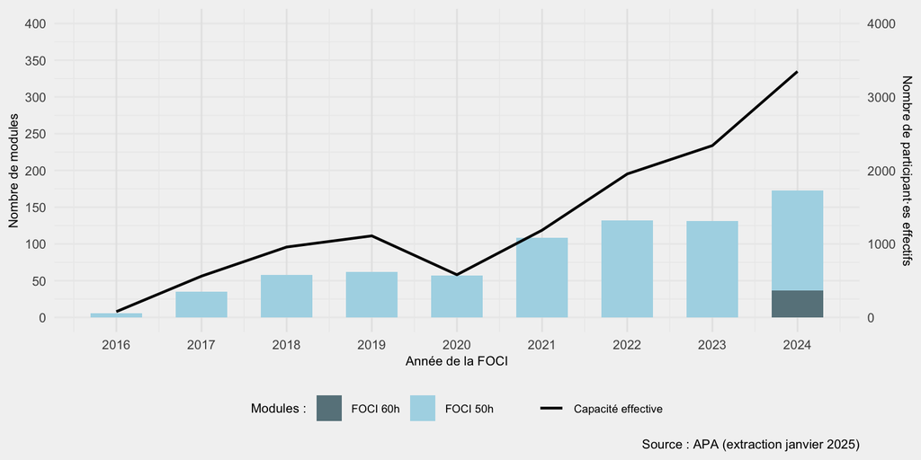

Figure 26: Évolution du nombre de bénéficiaires ayant suivi une FOCI et du nombre de FOCI (2017-2024).

En 2024, les modules de citoyenneté sont dispensés en **7 langues**[^57]. **La moitié des modules de citoyenneté sont en français,** parmi lesquelles 12% concernent des modules en français facile (modules destinés aux bénéficiaires ayant acquis le A2). En revanche, les **modules en arabe représentent 33 %** et perdent 6 pp. par rapport à 2023 et 14pp. par rapport à 2022. Comme annoncé pour les DD, depuis 2022 la part de bénéficiaires ayant une connaissance du français même si parfois partielle a augmenté davantage ce qui explique la diminution des modules en langues arabes. Les modules en anglais (16 %) diminuent également (-4 pp.) tandis que le nombre de modules en espagnol augmentent de 1 à 4 et des nouveaux modules ont été dispensés en farsi (2), en japonais (1) et en turc (1). Si les Bapas ont adapté l’offre linguistique des FOCI en accord avec la diversification des publics, des différences peuvent d’ailleurs être observées entre les Bapas selon les profils de leur public (cf. Rapport d’activités 2024 des Bapas).

En 2024, pour 10% des modules de FOCI, les Bapas ont fait appel à un·e interpréte extérieur·e et ce taux continue à diminuer par rapport à 2023. Il est possible que la difficulté à faire appel à un·e interprète, déjà mentionnée précédemment pour les DD, puisse expliquer la baisse de la part des modules avec interprètes en privilégiant des modules en français facile qui sont en augmentation.

Au total, 13 modules ont été dispensés en décalé, soit plus au moins 1 par mois tous Bapas confondus, et un de plus qu’en 2023. Les Bapas font des efforts pour mettre en place des modules en décalé mais les contraintes budgétaires limitent leur capacité à en organiser.

Dans leur rapport d’activités, les Bapas soulignent **plusieurs difficultés structurelles** :

- **Trouver des** **intérprètes** disponibles et avec des capacités pédagogiques ;
- **Faire valoir les congés éducation**. Le Bapa VIA souligne la difficulté des bénéficiaires à en faire la demande auprès de leur employeurs ;
- **Des capacités financières limitées**, ne permettant pas d’organiser davantage de modules, face à l’engorgement des Bapas. Cette contrainte budgétaire a pour conséquence, un temps prolongé entre l’inscription et le début effectif de la formation, due aussi à une augmentation des désistements et *in fine, il* en résulte une difficulté majeure à organiser les formations.

### 5.2.3 La formation linguistique

La formation linguistique est la seule composante qui **est mise en œuvre par des opérateurs tiers**. Les Bapas orientent leur public vers des organismes reconnus pour les formations de français et la HVN centralise l’offre néerlandophone (Art. 21, Arrêté COCOM 2024).

En ce qui concerne l’orientation vers les opérateurs francophones. Il en résulte une **collaboration nécessaire entre les Bapas** – qui réalisent les bilans linguistiques, inscrivent les bénéficiaires dans des modules de formation (et donc composent les groupes), et assurent le suivi de la formation (rappel du début, prise en charge des éventuels redoublements, etc.) – et **les opérateurs linguistiques** qui dispensent les formations et remettent l’attestation de suivi.

À ce titre, le tableau ci-dessous montre que les bénéficiaires qui doivent suivre une formation linguistique sont très largement (**92%**) orientés vers **les 16 opérateurs conventionnés**. La part des opérateurs conventionnés augmente légèrement par rapport à 2023 et le nombre de personnes inscrit·es auprès d’opérateurs reconnus en Cohésion Sociale, spécialisés dans l’alphabétisation (P2), chute : passant de 83 inscrit·es en 2023 à 14 en 2024.

| Type d'opérateur | Nombre d'inscriptions | Part (%) |
| --- | --- | --- |
| Bruxelles-Formation | 8 | 0.40 |
| Opérateurs conventionnés | 1829 | 91.77 |
| Opérateurs reconnus | 14 | 0.70 |
| Promotion sociale | 142 | 7.12 |
| Total | 1993 | 100.00 |

Source : APA (extraction janvier 2025)

Table 5: Répartition des bénéficiaires inscrit·es en formations linguistiques ayant réalisé un bilan linguistique en 2024 selon le type d’opérateurs.

En ce qui concerne la collaboration avec les OLs, tous les Bapas soulèvent **une grande amélioration dans la communication, la coordination de l’offre et le suivi des bénéficiaires**. Ils évoquent en particulier un échange fluide des documents importants (fiches de début et de fin de modules), des ajustements à faire (changements de groupe, de niveau, d’horaire) et des potentielles difficultés, d’apprentissage ou personnelle, que des bénéficiaires peuvent rencontrer[^58]. Toutefois, avec les Établissements de Promotion sociale (EPS) la collaboration se complique. Convivial explique d’une part, l’impossibilité d’inscrire un bénéficiaire à mi-parcours – avec un niveau « faux-débutant » (UE2/A2), d’autre part, l’absence d’envoi systématique des documents tels que les fiches de fin module[^59].

Si les Bapas saluent l’amélioration de la coordination de l’offre des opérateurs linguistiques ils évoquent la persistance de plusieurs difficultés :

- Difficultés liées au **manque de coordination géographique et temporelle de l’offre** : certaines filières commencent en même temps et dans le même secteur géographique. Il serait souhaitable de diversifier le temps et l’espace lors du début des modules. Cependant, VIA soulève une évolution positive avec l’étalement plus prononcé des débuts de filières[^60] ;
- Difficultés liées aux **redoublements**[^61]. Les Bapas ne sont prévenus des redoublements qu’à la fin du module, ce qui arrive souvent trop tard pour une réinscription immédiate. Sachant que des longs temps d’attente engendrent une perte cruciale dans l’apprentissage ;
- **Manque d’harmonisation des niveaux entre opérateurs linguistiques**. L’interchangeabilité des modules entre opérateurs devient plus difficile et le dispositif perd en efficacité. VIA souligne que “*Le travail en cours sur de nouveaux test FLE communs aux opérateurs linguistiques et aux BAPA va probablement contribuer à améliorer cette situation*”[^62]. ;
- **Difficulté à orienter certains bénéficiaires** cherchant à poursuivre leur formation linguistique **au-delà du niveau A2** (présumé) et/ou une offre au terme de laquelle une attestation valable dans le cadre de la demande de nationalité sera délivrée ;

**Regard sur les opérateurs linguistiques conventionnés**

Selon les chiffres de la COCOF[^63] relatifs à l’offre des **opérateurs linguistiques conventionnés, 3.577 inscriptions**[^64] à des modules de français ont été enregistrées en 2024. Il convient de préciser qu’une inscription correspond à l’enregistrement à un module spécifique : une même personne peut donc être comptabilisée plusieurs fois si elle a suivi plusieurs modules. La répartition des inscriptions par type de module est la suivante : **42% sont en FLE A, 26% en Alpha, 24% en FLE B et 8% en FLE NAL**. La sous-représentation du FLE B parmi les inscriptions, alors que 39,5% des bénéficiaires sont orienté·es vers cette filière, s’explique par la non-prise en compte des modules organisés par l’enseignement de Promotion Sociale, qui n’entrent pas dans le cadre des données COCOF.

Le taux global de désistement au module d’inscription, toutes filières confondues, est de 19%, principalement pour des raisons médicales ou professionnelles. Face à cette situation, les Bapas et les opérateurs linguistiques, travaillent conjointement afin de réduire ce taux. Toutefois, la gestion administrative des inscriptions et dans le cas contraire des désistements, centralisée exclusivement via l’accès des assistant·es sociaux·ales à l’APA, freine considérablement la réactivité pour remplacer les places libérées en début de module. **Les contraintes techniques et informatiques compliquent l’organisation et planification des modules**. Des mécanismes comme le *surbooking* ont été introduits pour compenser les absences en début de module. Toutefois, ces dispositifs demeurent insuffisants et peuvent s’avérer problématiques, notamment lorsque tous les apprenant·es se présentent, en raison du nombre limité de places dans les salles de cours.

Ensuite, les opérateurs linguistiques conventionnés ont dispensé **43.986 heures de cours en 2024** dont **58% en FLE et 42% en Alpha**. Si la répartition du taux horaire diffère de celle des inscriptions par filière, c’est parce que les groupes d’alphabétisation sont plus réduits que ceux du FLE - entre 15 et 20 bénéficiaires contre 12 pour l’Alpha. Par ailleurs, la demande de cours en filière alpha, et en moindre mesure de FLE B, a augmenté suite aux réformes de 2022 et notamment à la diversification des publics, au point d’être saturée en 2024.

Pour finir, des opérateurs linguistiques témoignent aussi de difficultés spécifiques au suivi des formations linguistiques. Premièrement, iels sont régulièrement confronté·es à des demandes d’accompagnement plus au moins complexes ou urgentes de la part des apprenant·es, en raison du lien de confiance qui se construit à travers le contact quotidien avec les apprenant·es. Il s’agit d’une réalité qui existe depuis toujours mais qui s’est vue renforcée depuis les réformes de 2022. Si la procédure prévoit une orientation des bénéficiaires vers leur assistant·e social référent·e du Bapa, la surcharge de travail de ces dernier·ères rend ces relais de plus en plus difficiles à mobiliser. Cette situation place les formateur·trices dans une tension accrue entre : répondre aux sollicitations, bien qu’iels ne soient ni mandaté·es et/ou formé·es pour cela, ou ne pas répondre, au risque de laisser une demande sans suite, faute de relais disponible.

Au niveau néerlandophone, les Bapas ne disposent pas de contact direct avec les opérateurs, ce qui limite le suivi des parcours linguistiques néerlandophones, notamment de l’absence de communication des résultats[^65]. Toutefois, le nombre restreint de dossiers néerlandophones ne permet pas d’établir une évaluation sur cette nouvelle modalité du Parcours d’accueil.

## 5.3 Les fins de parcours

### 5.3.1 L’évolution des parcours réalisés

La répartition selon le genre des bénéficiaires ayant obtenu une attestation en 2024 est, à 2 points de pourcentage près, similaire que celle des personnes admises (60%-40%), soit 62 % des femmes et 38% des hommes. Cela suggère que le rythme est globalement le même entre hommes et femmes.

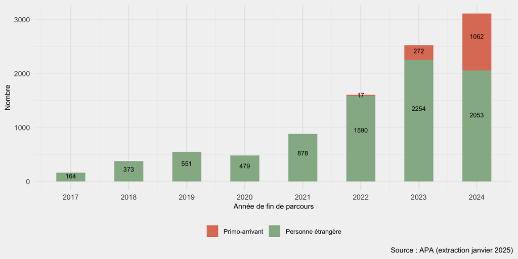

Figure 27: Évolution du nombre de parcours réalisés selon la catégorie des bénéficiaires (2017-2024)

Parmi les bénéficiaires ayant achevé leur parcours en 2024, **38% avaient été admis la même année**. Ce taux marque une baisse significative par rapport à 2023, qui avait enregistré un pic historique de 50%, taux le plus élevé depuis le début de la politique. Comparé aux années pré-pandémie ce taux reste toutefois supérieur. Pour comprendre ces évolutions et plus précisément le rythme de sortie il est indispensable d’analyser les durées de parcours.

### 5.3.2 Les durées du Parcours d’accueil

En prenant le temps de parcours des bénéficiaires ayant réalisé leur parcours en 2024 (n=3.029), en incluant les périodes de suspension[^66] mais **en excluant les doubles recours**, la durée moyenne est de 15 mois, tandis que **la durée médiane - plus pertinente au vu de certaines valeurs extrêmes (et aberrantes) - est de** **9 mois**. **Cette dernière a augmenté de 2,5 mois par rapport à 2023** (la moyenne est restée identique). Ceci peut notamment s’expliquer par une concentration progressive dans le parcours des profils avec le plus de besoins, et dont le parcours est ainsi plus long (eg. profils alpha).

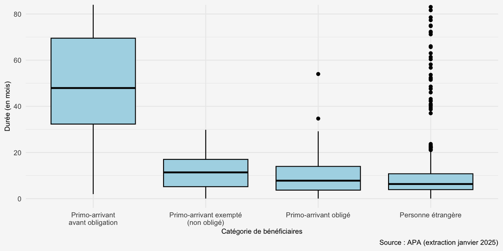

Figure 28: Distribution de la durée des parcours clôturés en 2024 selon la catégorie de bénéficiaires

| Catégorie de bénéfiaire | Effectif (n) | Proportion (%) | Médiane (mois) | Moyenne (mois) |
| --- | --- | --- | --- | --- |
| Personne étrangère | 1082 | 36 | 6 | 9 |
| Primo-arrivant obligé | 1045 | 34 | 8 | 9 |
| Primo-arrivant exempté (non obligé) | 560 | 18 | 11 | 13 |
| Primo-arrivant avant obligation | 342 | 11 | 48 | 51 |

Source : APA (extraction janvier 2025)

Table 6: Répartition des parcours clôturés en 2024 selon la catégorie de bénéficiaires

Cette **durée (médiane) de parcours se décline par ailleurs différemment selon les catégories de bénéficiaires** (Figure 28). On observe tout d’abord une nette différence entre les primo-arrivant·es qui ont intégré le dispositif avant l’entrée en vigueur de l’obligation (48 mois) et les bénéficiaires admis après juin 2022 (7,5 mois, contre 5 mois en 2023). Ceci peut s’expliquer d’un côté par le fait que les parcours des personnes primo-arrivantes avant l’obligation ont été impactés par la pandémie mondiale en 2020-21, et de l’autre par le fait que les bénéficiaires arrivées après les réformes de 2022 et ayant terminé en 2024 ont des profils sociaux et linguistiques qui leur permettent de réaliser le parcours plus vite (cf. *infra*). Parmi les catégories de bénéficiaires arrivé·es après les réformes de 2022, les durées médianes sont les suivantes :

- Les primo-arrivant·es exempté·es : 11 mois ;
- Les primo-arrivant·es obligé·es : 8 mois ;
- Les personnes étrangères (> 3 ans de séjour légal) : 6 mois.

- Les profils “Alpha” : 24 mois ;
- Les profils “FLE A” : 17 mois ;
- Les profils “FLE B” : 16 mois.